# Flourex Microbiome description

# INFO

This template is build to use the output from **GMH_import** as input. It will generate a general summary of the microbiome for the project, on all taxonomic levels, followed by a detailed summary where the group and subject variables is considered in the description.

The output will be observational, containing tables and plots, without any statistical analyses.

## PROJECT

This document has been fitted to perform beta diversity calculations of phyloseq element from the Import & QC script. It has been fitted for data from Flurex (internal project name: R20-22). The project data contains 16S V3 amplicon sequencing from feces samples from 4 different days and cecum and ileum samples from one day from 48 rats. There are feces samples from all rats from day 0, 2, 4 and 8. Cecum and ileum samples were all collected at dissection on day 8. Please read the method section for this paper for details on experimental setup.

## VARIABLES

Metadata contains sample information regarding: - rat number/name, cage number (rats were co-caged 2-2), day of sampling, material (feces, cecum, ileum), sequencing information (gram of material used for extracted DNA, DNA concentrations, primers, barcodes for demultiplexing, batch number (“run” = c2, c3, c4)), treatment groups. Several columns have been created for easy sample grouping during analysis, including for distinguishing between vancomycin and PFOS treatment alone.

Metadata contains results from: - Bodyweight per sampling day, while cecum and liver weight for day 8 (addition column with organ weights normalised to bodyweight).

- PFOS quantification of:
  - Blood serum from day 4 and 8 measured in µg/mL
  - Liver tissue from day 8 measured in mg PFOS in full liver weight
- Short-chain fatty acids quantification of 10 compounds in colonic water given in mM from day 8: acetic acid, formic acid, propanoic acid, 2methyl-propanoic acid, butanoic acid, 3methyl-butanoic acid, pentanoic acid, 4methyl-pentanoic acid, hexanoic acid and heptanoic acid

# FORMAT DATA

# OVERALL

This section produces a general description of the data with the plots grouped by the group_var, but without using any other metadata.

If there are no relevant groups in this part of the analysis it can also be used to indicate batches. If no groups or batches exist, then please create a variable that just indicate the project name for all samples.

## PHYLUM

### COUNTS

At phylum level the microbiome counts are as follows

```r
# load data
load("R_objects/Agglomerated.RData")
params <- readRDS( "R_objects/params_description")

# Transform data
phy.rel <- transform_sample_counts(phy.ph, fun = function(x) x/sum(x)*100)
dat <- psmelt(phy.rel)
# summarise per sample
sumsample <- dat %>%
  filter(Abundance > 0) %>%
  group_by(Sample) %>%
  summarise(pct_0 = n(),
            pct_0.1 = sum(Abundance < 0.1),
            pct_0_1 = sum(Abundance >= 0.1 & Abundance < 1),
            pct_1_10 = sum(Abundance >= 1 & Abundance < 10),
            pct_10 = sum(Abundance > 10)) %>%
  pivot_longer(-Sample,
               names_to = c("Cutoff"),
               values_to = "Count") %>%
  group_by(Cutoff) %>%
  summarise(sample_mean = mean(Count),
            sample_sd = sd(Count))

# summarise total
sumall <- dat %>%
  filter(Abundance > 0) %>%
  group_by(OTU) %>%
  summarise(Abundance = mean(Abundance)) %>%
  summarise(pct_0 = n(),
            pct_0.1 = sum(Abundance < 0.1),
            pct_0_1 = sum(Abundance >= 0.1 & Abundance < 1),
            pct_1_10 = sum(Abundance >= 1 & Abundance < 10),
            pct_10 = sum(Abundance > 10)) %>%
  pivot_longer(cols = everything(),
               names_to = c("Cutoff"),
               values_to = "Count")

# Combine
output <- full_join(sumall, sumsample)
output$Cutoff <- c("All", "n < 0.1%", "0.1% < n < 1.0%", "1.0% < n < 10%", "10%  < n")

# Create output table
kable(output, row.names = F,digits = 2, caption = 'Count of phyla in general and per sample',align = "r") %>%
  kable_classic(full_width = F, position = "left")
```

Count of phyla in general and per sample

| Cutoff | Count | sample_mean | sample_sd |
| --- | --- | --- | --- |
| All | 9 | 5.99 | 0.70 |
| n < 0.1% | 5 | 1.89 | 0.88 |
| 0.1% < n < 1.0% | 0 | 0.74 | 0.66 |
| 1.0% < n < 10% | 0 | 0.97 | 0.75 |
| 10% < n | 4 | 2.39 | 0.62 |

### PLOTS

To improve the interpretation of the compositional plots I will pretreat the data with three steps:

1. Filter taxa by average abundance (minimum 1 %) and rank (max 19 features + “Others”)
2. Sort the plotted taxa by full phylogeny
3. Change taxa names in plot to a letter and include table of full taxonomy

```r
# Filter by abundance, then rank
phy.top <- filter_abundance(phy.rel) %>% filter_rank(min.rank = 19)
```

```
## 7 features grouped as 'Others' in the output
```

```
## 1 features grouped as 'Others' in the output
```

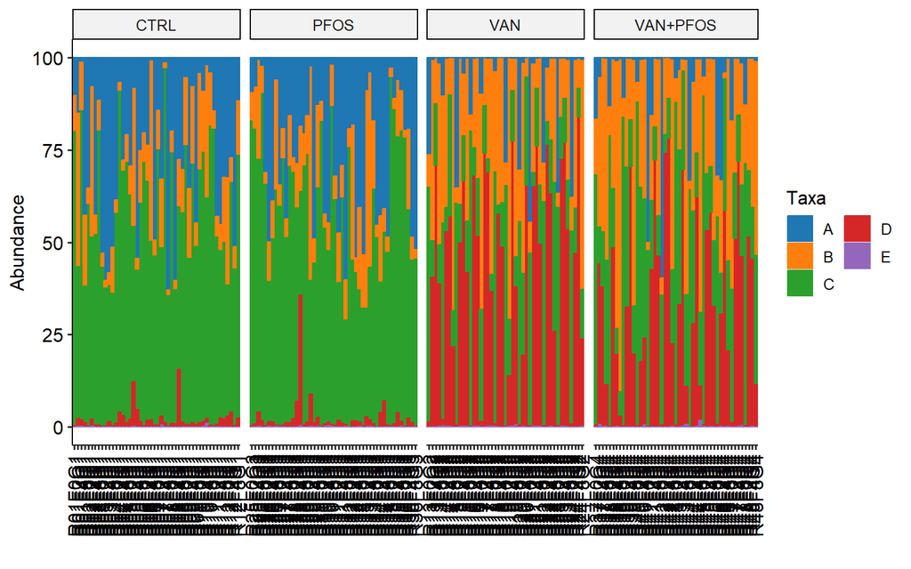

```r
#Melt data
dat <- suppressWarnings(psmelt(phy.top))
colnames(dat)[c(1,4)] <- c("Taxa","SampleID")

# Sort taxa
dat.sort <- sort_taxa(dat)

# rename taxa
levels(dat.sort$Taxa) <- LETTERS[seq(length(levels(dat.sort$Taxa)))]

# Create plot
p <- ggplot(dat.sort, aes(x = SampleID,
                          y = Abundance,
                          fill = Taxa,
                          color = Taxa)) +
  geom_col() +
  xlab("") +
  facet_grid(. ~ get(params$group_var),space = "free_x",scales = "free_x") +
  ggsci::scale_color_d3(palette = "category20") +
  ggsci::scale_fill_d3(palette = "category20") +
  guides(fill=guide_legend(ncol=2), color=guide_legend(ncol=2)) +
  theme_pubr(legend = "right") + rotate_x_text(angle = 90)
p
```

```r
# print tax table
# print tax table
tax <- dat.sort %>% group_by(Taxa, Kingdom, Phylum) %>% summarise(Abundance = mean(Abundance))
```

```r
kable(tax,digits = 2,caption = paste("Taxa plotted", sep = " ")) %>%
  kable_classic(full_width = F, position = "left")
```

Taxa plotted

| Taxa | Kingdom | Phylum | Abundance |
| --- | --- | --- | --- |
| A | Bacteria | Actinobacteria | 17.21 |
| B | Bacteria | Bacteroidetes | 21.07 |
| C | Bacteria | Firmicutes | 43.56 |
| D | Bacteria | Proteobacteria | 18.05 |
| E | Others | Others | 0.10 |

```r
# clear the environment and release memory
rm(list = ls(all.names = TRUE))
invisible(gc())
```

## CLASS

### COUNTS

At class level the microbiome counts are as follows

```r
# load data
load("R_objects/Agglomerated.RData")
params <- readRDS( "R_objects/params_description")

# Transform data
phy.rel <- transform_sample_counts(phy.cl, fun = function(x) x/sum(x)*100)
dat <- psmelt(phy.rel)
# summarise per sample
sumsample <- dat %>%
  filter(Abundance > 0) %>%
  group_by(Sample) %>%
  summarise(pct_0 = n(),
            pct_0.1 = sum(Abundance < 0.1),
            pct_0_1 = sum(Abundance >= 0.1 & Abundance < 1),
            pct_1_10 = sum(Abundance >= 1 & Abundance < 10),
            pct_10 = sum(Abundance > 10)) %>%
  pivot_longer(-Sample,
               names_to = c("Cutoff"),
               values_to = "Count") %>%
  group_by(Cutoff) %>%
  summarise(sample_mean = mean(Count),
            sample_sd = sd(Count))

# summarise total
sumall <- dat %>%
  filter(Abundance > 0) %>%
  group_by(OTU) %>%
  summarise(Abundance = mean(Abundance)) %>%
  summarise(pct_0 = n(),
            pct_0.1 = sum(Abundance < 0.1),
            pct_0_1 = sum(Abundance >= 0.1 & Abundance < 1),
            pct_1_10 = sum(Abundance >= 1 & Abundance < 10),
            pct_10 = sum(Abundance > 10)) %>%
  pivot_longer(cols = everything(),
               names_to = c("Cutoff"),
               values_to = "Count")

# Combine
output <- full_join(sumall, sumsample)
output$Cutoff <- c("All", "n < 0.1%", "0.1% < n < 1.0%", "1.0% < n < 10%", "10%  < n")

# Create output table
kable(output, row.names = F,digits = 2, caption = 'Count of classes in general and per sample') %>%
  kable_classic(full_width = F, position = "left")
```

Count of classes in general and per sample

| Cutoff | Count | sample_mean | sample_sd |
| --- | --- | --- | --- |
| All | 22 | 13.58 | 1.35 |
| n < 0.1% | 12 | 5.26 | 1.43 |
| 0.1% < n < 1.0% | 4 | 3.01 | 1.11 |
| 1.0% < n < 10% | 1 | 2.59 | 1.06 |
| 10% < n | 5 | 2.73 | 0.73 |

### PLOTS

To improve the interpretation of the compositional plots I will pretreat the data with three steps:

1. Filter taxa by average abundance (minimum 1 %) and rank (max 19 features + “Others”)
2. Sort the plotted taxa by full phylogeny
3. Change taxa names in plot to a letter and include table of full taxonomy

```r
# Filter by abundance, then rank
phy.top <- filter_abundance(phy.rel) %>% filter_rank(min.rank = 19)
```

```
## 18 features grouped as 'Others' in the output
```

```
## 1 features grouped as 'Others' in the output
```

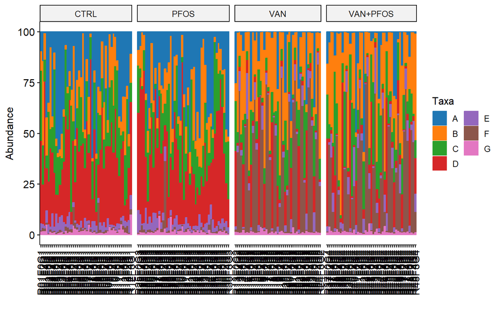

```r
#Melt data
dat <- suppressWarnings(psmelt(phy.top))
colnames(dat)[c(1,4)] <- c("Taxa","SampleID")

# Sort taxa
dat.sort <- sort_taxa(dat)

# rename taxa
levels(dat.sort$Taxa) <- LETTERS[seq(length(levels(dat.sort$Taxa)))]

# Create plot
p <- ggplot(dat.sort, aes(x = SampleID,
                          y = Abundance,
                          fill = Taxa,
                          color = Taxa)) +
  geom_col() +
  xlab("") +
  facet_grid(. ~ get(params$group_var),space = "free_x",scales = "free_x") +
  ggsci::scale_color_d3(palette = "category20") +
  ggsci::scale_fill_d3(palette = "category20") +
  guides(fill=guide_legend(ncol=2), color=guide_legend(ncol=2)) +
  theme_pubr(legend = "right") + rotate_x_text(angle = 90)
p
```

```r
# print tax table
# print tax table
tax <- dat.sort %>% group_by(Taxa, Kingdom, Phylum, Class) %>% summarise(Abundance = mean(Abundance))
```

```r
kable(tax,digits = 2,caption = paste("Taxa plotted", sep = " ")) %>%
  kable_classic(full_width = F, position = "left")
```

Taxa plotted

| Taxa | Kingdom | Phylum | Class | Abundance |
| --- | --- | --- | --- | --- |
| A | Bacteria | Actinobacteria | Actinobacteria | 16.80 |
| B | Bacteria | Bacteroidetes | Bacteroidia | 21.07 |
| C | Bacteria | Firmicutes | Bacilli | 15.80 |
| D | Bacteria | Firmicutes | Clostridia | 22.95 |
| E | Bacteria | Firmicutes | Erysipelotrichia | 4.43 |
| F | Bacteria | Proteobacteria | Gammaproteobacteria | 17.27 |
| G | Others | Others | Others | 1.68 |

```r
# clear the environment and release memory
rm(list = ls(all.names = TRUE))
invisible(gc())
```

## ORDER

### COUNTS

At order level the microbiome counts are as follows

```r
# load data
load("R_objects/Agglomerated.RData")
params <- readRDS( "R_objects/params_description")

# Transform data
phy.rel <- transform_sample_counts(phy.or, fun = function(x) x/sum(x)*100)
dat <- psmelt(phy.rel)
# summarise per sample
sumsample <- dat %>%
  filter(Abundance > 0) %>%
  group_by(Sample) %>%
  summarise(pct_0 = n(),
            pct_0.1 = sum(Abundance < 0.1),
            pct_0_1 = sum(Abundance >= 0.1 & Abundance < 1),
            pct_1_10 = sum(Abundance >= 1 & Abundance < 10),
            pct_10 = sum(Abundance > 10)) %>%
  pivot_longer(-Sample,
               names_to = c("Cutoff"),
               values_to = "Count") %>%
  group_by(Cutoff) %>%
  summarise(sample_mean = mean(Count),
            sample_sd = sd(Count))

# summarise total
sumall <- dat %>%
  filter(Abundance > 0) %>%
  group_by(OTU) %>%
  summarise(Abundance = mean(Abundance)) %>%
  summarise(pct_0 = n(),
            pct_0.1 = sum(Abundance < 0.1),
            pct_0_1 = sum(Abundance >= 0.1 & Abundance < 1),
            pct_1_10 = sum(Abundance >= 1 & Abundance < 10),
            pct_10 = sum(Abundance > 10)) %>%
  pivot_longer(cols = everything(),
               names_to = c("Cutoff"),
               values_to = "Count")

# Combine
output <- full_join(sumall, sumsample)
output$Cutoff <- c("All", "n < 0.1%", "0.1% < n < 1.0%", "1.0% < n < 10%", "10%  < n")

# Create output table
kable(output, row.names = F,digits = 2, caption = 'Count of phyla in general and per sample',align = "r") %>%
  kable_classic(full_width = F, position = "left")
```

Count of phyla in general and per sample

| Cutoff | Count | sample_mean | sample_sd |
| --- | --- | --- | --- |
| All | 32 | 18.12 | 2.03 |
| n < 0.1% | 21 | 9.19 | 1.91 |
| 0.1% < n < 1.0% | 5 | 3.60 | 1.33 |
| 1.0% < n < 10% | 1 | 2.60 | 1.08 |
| 10% < n | 5 | 2.73 | 0.73 |

### PLOTS

To improve the interpretation of the compositional plots I will pretreat the data with three steps:

1. Filter taxa by average abundance (minimum 1 %) and rank (max 19 features + “Others”)
2. Sort the plotted taxa by full phylogeny
3. Change taxa names in plot to a letter and include table of full taxonomy

```r
# Filter by abundance, then rank
phy.top <- filter_abundance(phy.rel) %>% filter_rank(min.rank = 19)
```

```
## 36 features grouped as 'Others' in the output
```

```
## 1 features grouped as 'Others' in the output
```

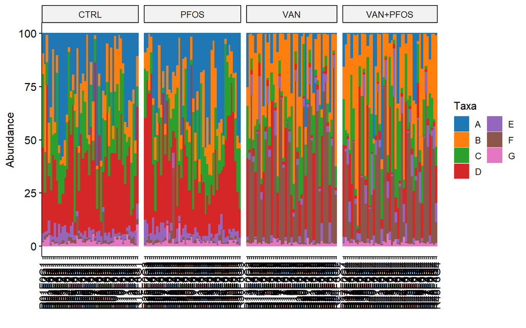

```r
#Melt data
dat <- suppressWarnings(psmelt(phy.top))
colnames(dat)[c(1,4)] <- c("Taxa","SampleID")

# Sort taxa
dat.sort <- sort_taxa(dat)

# rename taxa
levels(dat.sort$Taxa) <- LETTERS[seq(length(levels(dat.sort$Taxa)))]

# Create plot
p <- ggplot(dat.sort, aes(x = SampleID,
                          y = Abundance,
                          fill = Taxa,
                          color = Taxa)) +
  geom_col() +
  xlab("") +
  facet_grid(. ~ get(params$group_var),space = "free_x",scales = "free_x") +
  ggsci::scale_color_d3(palette = "category20") +
  ggsci::scale_fill_d3(palette = "category20") +
  guides(fill=guide_legend(ncol=2), color=guide_legend(ncol=2)) +
  theme_pubr(legend = "right") + rotate_x_text(angle = 90)
p
```

```r
# print tax table
# print tax table
tax <- dat.sort %>% group_by(Taxa, Kingdom, Phylum, Class, Order) %>% summarise(Abundance = mean(Abundance))
```

```
## can override using the `.groups` argument.
```

```r
kable(tax,digits = 2,caption = paste("Taxa plotted", sep = " ")) %>%
  kable_classic(full_width = F, position = "left")
```

Taxa plotted

| Taxa | Kingdom | Phylum | Class | Order | Abundance |
| --- | --- | --- | --- | --- | --- |
| A | Bacteria | Actinobacteria | Actinobacteria | Bifidobacteriales | 16.76 |
| B | Bacteria | Bacteroidetes | Bacteroidia | Bacteroidales | 21.07 |
| C | Bacteria | Firmicutes | Bacilli | Lactobacillales | 15.76 |
| D | Bacteria | Firmicutes | Clostridia | Clostridiales | 22.76 |
| E | Bacteria | Firmicutes | Erysipelotrichia | Erysipelotrichales | 4.43 |
| F | Bacteria | Proteobacteria | Gammaproteobacteria | Enterobacterales | 17.27 |
| G | Others | Others | Others | Others | 1.95 |

```r
# clear the environment and release memory
rm(list = ls(all.names = TRUE))
invisible(gc())
```

## FAMILY

### COUNTS

At family level the microbiome counts are as follows

```r
# load data
load("R_objects/Agglomerated.RData")
params <- readRDS( "R_objects/params_description")

# Transform data
phy.rel <- transform_sample_counts(phy.fa, fun = function(x) x/sum(x)*100)
dat <- psmelt(phy.rel)
# summarise per sample
sumsample <- dat %>%
  filter(Abundance > 0) %>%
  group_by(Sample) %>%
  summarise(pct_0 = n(),
            pct_0.1 = sum(Abundance < 0.1),
            pct_0_1 = sum(Abundance >= 0.1 & Abundance < 1),
            pct_1_10 = sum(Abundance >= 1 & Abundance < 10),
            pct_10 = sum(Abundance > 10)) %>%
  pivot_longer(-Sample,
               names_to = c("Cutoff"),
               values_to = "Count") %>%
  group_by(Cutoff) %>%
  summarise(sample_mean = mean(Count),
            sample_sd = sd(Count))

# summarise total
sumall <- dat %>%
  filter(Abundance > 0) %>%
  group_by(OTU) %>%
  summarise(Abundance = mean(Abundance)) %>%
  summarise(pct_0 = n(),
            pct_0.1 = sum(Abundance < 0.1),
            pct_0_1 = sum(Abundance >= 0.1 & Abundance < 1),
            pct_1_10 = sum(Abundance >= 1 & Abundance < 10),
            pct_10 = sum(Abundance > 10)) %>%
  pivot_longer(cols = everything(),
               names_to = c("Cutoff"),
               values_to = "Count")

# Combine
output <- full_join(sumall, sumsample)
output$Cutoff <- c("All", "n < 0.1%", "0.1% < n < 1.0%", "1.0% < n < 10%", "10%  < n")

# Create output table
kable(output, row.names = F,digits = 2, caption = 'Count of phyla in general and per sample',align = "r") %>%
  kable_classic(full_width = F, position = "left")
```

Count of phyla in general and per sample

| Cutoff | Count | sample_mean | sample_sd |
| --- | --- | --- | --- |
| All | 60 | 32.62 | 4.32 |
| n < 0.1% | 37 | 16.76 | 3.02 |
| 0.1% < n < 1.0% | 13 | 7.89 | 2.49 |
| 1.0% < n < 10% | 5 | 5.17 | 2.37 |
| 10% < n | 5 | 2.80 | 0.87 |

### PLOTS

To improve the interpretation of the compositional plots I will pretreat the data with three steps:

1. Filter taxa by average abundance (minimum 1 %) and rank (max 19 features + “Others”)
2. Sort the plotted taxa by full phylogeny
3. Change taxa names in plot to a letter and include table of full taxonomy

```r
# Filter by abundance, then rank
phy.top <- filter_abundance(phy.rel) %>% filter_rank(min.rank = 19)
```

```
## 70 features grouped as 'Others' in the output
```

```
## 1 features grouped as 'Others' in the output
```

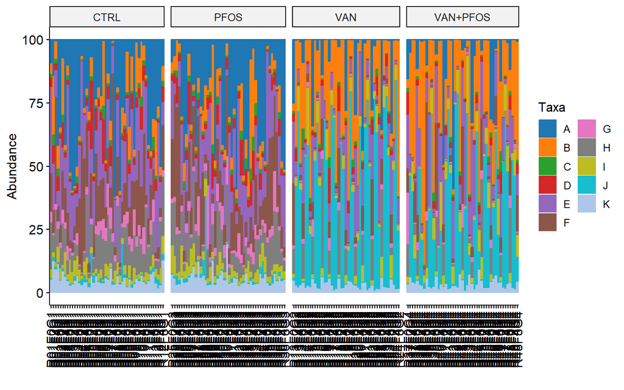

```r
#Melt data
dat <- suppressWarnings(psmelt(phy.top))
colnames(dat)[c(1,4)] <- c("Taxa","SampleID")

# Sort taxa
dat.sort <- sort_taxa(dat)

# rename taxa
levels(dat.sort$Taxa) <- LETTERS[seq(length(levels(dat.sort$Taxa)))]

# Create plot
p <- ggplot(dat.sort, aes(x = SampleID,
                          y = Abundance,
                          fill = Taxa,
                          color = Taxa)) +
  geom_col() +
  xlab("") +
  facet_grid(. ~ get(params$group_var),space = "free_x",scales = "free_x") +
  ggsci::scale_color_d3(palette = "category20") +
  ggsci::scale_fill_d3(palette = "category20") +
  guides(fill=guide_legend(ncol=2), color=guide_legend(ncol=2)) +
  theme_pubr(legend = "right") + rotate_x_text(angle = 90)
p
```

```r
# print tax table
# print tax table
tax <- dat.sort %>% group_by(Taxa, Kingdom, Phylum, Class, Order, Family) %>% summarise(Abundance = mean(Abundance))
```

```
## 'Order'. You can override using the `.groups` argument.
```

```r
kable(tax,digits = 2,caption = paste("Taxa plotted", sep = " ")) %>%
  kable_classic(full_width = F, position = "left")
```

Taxa plotted

| Taxa | Kingdom | Phylum | Class | Order | Family | Abundance |
| --- | --- | --- | --- | --- | --- | --- |
| A | Bacteria | Actinobacteria | Actinobacteria | Bifidobacteriales | Bifidobacteriaceae | 16.76 |
| B | Bacteria | Bacteroidetes | Bacteroidia | Bacteroidales | Bacteroidaceae | 16.41 |
| C | Bacteria | Bacteroidetes | Bacteroidia | Bacteroidales | Porphyromonadaceae | 1.03 |
| D | Bacteria | Bacteroidetes | Bacteroidia | Bacteroidales | Prevotellaceae | 3.07 |
| E | Bacteria | Firmicutes | Bacilli | Lactobacillales | Lactobacillaceae | 15.66 |
| F | Bacteria | Firmicutes | Clostridia | Clostridiales | Lachnospiraceae | 10.81 |
| G | Bacteria | Firmicutes | Clostridia | Clostridiales | Order_Clostridiales | 2.35 |
| H | Bacteria | Firmicutes | Clostridia | Clostridiales | Ruminococcaceae | 7.89 |
| I | Bacteria | Firmicutes | Erysipelotrichia | Erysipelotrichales | Erysipelotrichaceae | 4.43 |
| J | Bacteria | Proteobacteria | Gammaproteobacteria | Enterobacterales | Enterobacteriaceae | 17.27 |
| K | Others | Others | Others | Others | Others | 4.32 |

```r
# clear the environment and release memory
rm(list = ls(all.names = TRUE))
invisible(gc())
```

## GENUS

### COUNTS

At genus level the microbiome counts are as follows

```r
# load data
load("R_objects/Agglomerated.RData")
params <- readRDS( "R_objects/params_description")

# Transform data
phy.rel <- transform_sample_counts(phy.ge, fun = function(x) x/sum(x)*100)
dat <- psmelt(phy.rel)
# summarise per sample
sumsample <- dat %>%
  filter(Abundance > 0) %>%
  group_by(Sample) %>%
  summarise(pct_0 = n(),
            pct_0.1 = sum(Abundance < 0.1),
            pct_0_1 = sum(Abundance >= 0.1 & Abundance < 1),
            pct_1_10 = sum(Abundance >= 1 & Abundance < 10),
            pct_10 = sum(Abundance > 10)) %>%
  pivot_longer(-Sample,
               names_to = c("Cutoff"),
               values_to = "Count") %>%
  group_by(Cutoff) %>%
  summarise(sample_mean = mean(Count),
            sample_sd = sd(Count))

# summarise total
sumall <- dat %>%
  filter(Abundance > 0) %>%
  group_by(OTU) %>%
  summarise(Abundance = mean(Abundance)) %>%
  summarise(pct_0 = n(),
            pct_0.1 = sum(Abundance < 0.1),
            pct_0_1 = sum(Abundance >= 0.1 & Abundance < 1),
            pct_1_10 = sum(Abundance >= 1 & Abundance < 10),
            pct_10 = sum(Abundance > 10)) %>%
  pivot_longer(cols = everything(),
               names_to = c("Cutoff"),
               values_to = "Count")

# Combine
output <- full_join(sumall, sumsample)
output$Cutoff <- c("All", "n < 0.1%", "0.1% < n < 1.0%", "1.0% < n < 10%", "10%  < n")

# Create output table
kable(output, row.names = F,digits = 2, caption = 'Count of genera in general and per sample',align = "r") %>%
  kable_classic(full_width = F, position = "left")
```

Count of genera in general and per sample

| Cutoff | Count | sample_mean | sample_sd |
| --- | --- | --- | --- |
| All | 136 | 63.41 | 16.34 |
| n < 0.1% | 88 | 39.18 | 9.42 |
| 0.1% < n < 1.0% | 34 | 14.96 | 6.29 |
| 1.0% < n < 10% | 11 | 6.71 | 3.29 |
| 10% < n | 3 | 2.56 | 0.89 |

### PLOTS

To improve the interpretation of the compositional plots I will pretreat the data with three steps:

1. Filter taxa by average abundance (minimum 1 %) and rank (max 19 features + “Others”)
2. Sort the plotted taxa by full phylogeny
3. Change taxa names in plot to a letter and include table of full taxonomy

```r
# Filter by abundance, then rank
phy.top <- filter_abundance(phy.rel) %>% filter_rank(min.rank = 19)
```

```
## 160 features grouped as 'Others' in the output
```

```
## 1 features grouped as 'Others' in the output
```

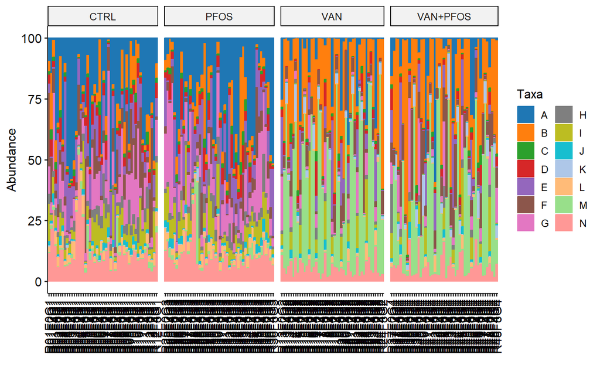

```r
#Melt data
dat <- suppressWarnings(psmelt(phy.top))
colnames(dat)[c(1,4)] <- c("Taxa","SampleID")

# Sort taxa
dat.sort <- sort_taxa(dat)

# rename taxa
levels(dat.sort$Taxa) <- LETTERS[seq(length(levels(dat.sort$Taxa)))]

# Create plot
p <- ggplot(dat.sort, aes(x = SampleID,
                          y = Abundance,
                          fill = Taxa,
                          color = Taxa)) +
  geom_col() +
  xlab("") +
  facet_grid(. ~ get(params$group_var),space = "free_x",scales = "free_x") +
  ggsci::scale_color_d3(palette = "category20") +
  ggsci::scale_fill_d3(palette = "category20") +
  guides(fill=guide_legend(ncol=2), color=guide_legend(ncol=2)) +
  theme_pubr(legend = "right") + rotate_x_text(angle = 90)
p
```

```r
# print tax table
# print tax table
tax <- dat.sort %>% group_by(Taxa, Kingdom, Phylum, Class, Order, Family, Genus) %>% summarise(Abundance = mean(Abundance))
```

```
## 'Order', 'Family'. You can override using the `.groups` argument.
```

```r
kable(tax,digits = 2,caption = paste("Taxa plotted", sep = " ")) %>%
  kable_classic(full_width = F, position = "left")
```

Taxa plotted

| Taxa | Kingdom | Phylum | Class | Order | Family | Genus | Abundance |
| --- | --- | --- | --- | --- | --- | --- | --- |
| A | Bacteria | Actinobacteria | Actinobacteria | Bifidobacteriales | Bifidobacteriaceae | Bifidobacterium | 16.76 |
| B | Bacteria | Bacteroidetes | Bacteroidia | Bacteroidales | Bacteroidaceae | Bacteroides | 16.41 |
| C | Bacteria | Bacteroidetes | Bacteroidia | Bacteroidales | Porphyromonadaceae | Parabacteroides | 1.03 |
| D | Bacteria | Bacteroidetes | Bacteroidia | Bacteroidales | Prevotellaceae | Prevotellamassilia | 3.07 |
| E | Bacteria | Firmicutes | Bacilli | Lactobacillales | Lactobacillaceae | Lactobacillus | 8.05 |
| F | Bacteria | Firmicutes | Bacilli | Lactobacillales | Lactobacillaceae | Ligilactobacillus | 7.62 |
| G | Bacteria | Firmicutes | Clostridia | Clostridiales | Lachnospiraceae | Family_Lachnospiraceae | 8.65 |
| H | Bacteria | Firmicutes | Clostridia | Clostridiales | Order_Clostridiales | Order_Clostridiales | 2.35 |
| I | Bacteria | Firmicutes | Clostridia | Clostridiales | Ruminococcaceae | Family_Ruminococcaceae | 5.39 |
| J | Bacteria | Firmicutes | Clostridia | Clostridiales | Ruminococcaceae | Intestinimonas | 1.12 |
| K | Bacteria | Firmicutes | Erysipelotrichia | Erysipelotrichales | Erysipelotrichaceae | Holdemania | 1.48 |
| L | Bacteria | Firmicutes | Erysipelotrichia | Erysipelotrichales | Erysipelotrichaceae | Turicibacter | 1.95 |
| M | Bacteria | Proteobacteria | Gammaproteobacteria | Enterobacterales | Enterobacteriaceae | Escherichia/Shigella | 17.20 |
| N | Others | Others | Others | Others | Others | Others | 8.94 |

```r
# clear the environment and release memory
rm(list = ls(all.names = TRUE))
invisible(gc())
```

## SPECIES

### COUNTS

At species level the microbiome counts are as follows

```r
# load data
load("R_objects/Agglomerated.RData")
params <- readRDS( "R_objects/params_description")

# Transform data
phy.rel <- transform_sample_counts(phy.sp, fun = function(x) x/sum(x)*100)
dat <- psmelt(phy.rel)
# summarise per sample
sumsample <- dat %>%
  filter(Abundance > 0) %>%
  group_by(Sample) %>%
  summarise(pct_0 = n(),
            pct_0.1 = sum(Abundance < 0.1),
            pct_0_1 = sum(Abundance >= 0.1 & Abundance < 1),
            pct_1_10 = sum(Abundance >= 1 & Abundance < 10),
            pct_10 = sum(Abundance > 10)) %>%
  pivot_longer(-Sample,
               names_to = c("Cutoff"),
               values_to = "Count") %>%
  group_by(Cutoff) %>%
  summarise(sample_mean = mean(Count),
            sample_sd = sd(Count))

# summarise total
sumall <- dat %>%
  filter(Abundance > 0) %>%
  group_by(OTU) %>%
  summarise(Abundance = mean(Abundance)) %>%
  summarise(pct_0 = n(),
            pct_0.1 = sum(Abundance < 0.1),
            pct_0_1 = sum(Abundance >= 0.1 & Abundance < 1),
            pct_1_10 = sum(Abundance >= 1 & Abundance < 10),
            pct_10 = sum(Abundance > 10)) %>%
  pivot_longer(cols = everything(),
               names_to = c("Cutoff"),
               values_to = "Count")

# Combine
output <- full_join(sumall, sumsample)
output$Cutoff <- c("All", "n < 0.1%", "0.1% < n < 1.0%", "1.0% < n < 10%", "10%  < n")

# Create output table
kable(output, row.names = F,digits = 2, caption = 'Count of phyla in general and per sample',align = "r") %>%
  kable_classic(full_width = F, position = "left")
```

Count of phyla in general and per sample

| Cutoff | Count | sample_mean | sample_sd |
| --- | --- | --- | --- |
| All | 173 | 75.39 | 19.11 |
| n < 0.1% | 119 | 48.72 | 11.58 |
| 0.1% < n < 1.0% | 38 | 16.57 | 6.71 |
| 1.0% < n < 10% | 14 | 7.57 | 3.51 |
| 10% < n | 2 | 2.53 | 0.88 |

### PLOTS

To improve the interpretation of the compositional plots I will pretreat the data with three steps:

1. Filter taxa by average abundance (minimum 1 %) and rank (max 19 features + “Others”)
2. Sort the plotted taxa by full phylogeny
3. Change taxa names in plot to a letter and include table of full taxonomy

```r
# Filter by abundance, then rank
phy.top <- filter_abundance(phy.rel) %>% filter_rank(min.rank = 19)
```

```
## 213 features grouped as 'Others' in the output
```

```
## 1 features grouped as 'Others' in the output
```

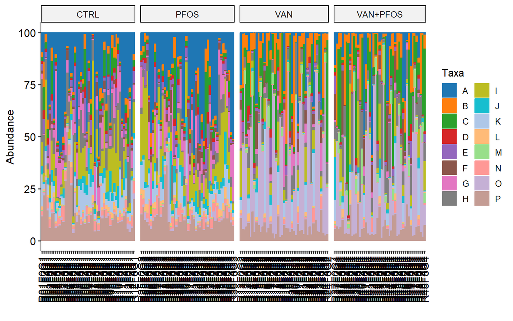

```r
#Melt data
dat <- suppressWarnings(psmelt(phy.top))
colnames(dat)[c(1,4)] <- c("Taxa","SampleID")

# Sort taxa
dat.sort <- sort_taxa(dat)

# rename taxa
levels(dat.sort$Taxa) <- LETTERS[seq(length(levels(dat.sort$Taxa)))]

# Create plot
p <- ggplot(dat.sort, aes(x = SampleID,
                          y = Abundance,
                          fill = Taxa,
                          color = Taxa)) +
  geom_col() +
  xlab("") +
  facet_grid(. ~ get(params$group_var),space = "free_x",scales = "free_x") +
  ggsci::scale_color_d3(palette = "category20") +
  ggsci::scale_fill_d3(palette = "category20") +
  guides(fill=guide_legend(ncol=2), color=guide_legend(ncol=2)) +
  theme_pubr(legend = "right") + rotate_x_text(angle = 90)
p
```

```r
# print tax table
tax <- dat.sort %>% group_by(Taxa, Kingdom, Phylum, Class, Order, Family, Genus, Species) %>% summarise(Abundance = mean(Abundance))
```

```
## 'Order', 'Family', 'Genus'. You can override using the `.groups` argument.
```

```r
kable(tax,digits = 2,caption = paste("Taxa plotted", sep = " ")) %>%
  kable_classic(full_width = F, position = "left")
```

Taxa plotted

| Taxa | Kingdom | Phylum | Class | Order | Family | Genus | Species | Abundance |
| --- | --- | --- | --- | --- | --- | --- | --- | --- |
| A | Bacteria | Actinobacteria | Actinobacteria | Bifidobacteriales | Bifidobacteriaceae | Bifidobacterium | pseudolongum | 16.67 |
| B | Bacteria | Bacteroidetes | Bacteroidia | Bacteroidales | Bacteroidaceae | Bacteroides | thetaiotaomicron | 6.44 |
| C | Bacteria | Bacteroidetes | Bacteroidia | Bacteroidales | Bacteroidaceae | Bacteroides | xylanisolvens | 9.93 |
| D | Bacteria | Bacteroidetes | Bacteroidia | Bacteroidales | Porphyromonadaceae | Parabacteroides | goldsteinii | 1.03 |
| E | Bacteria | Bacteroidetes | Bacteroidia | Bacteroidales | Prevotellaceae | Prevotellamassilia | Genus_Prevotellamassilia | 3.07 |
| F | Bacteria | Firmicutes | Bacilli | Lactobacillales | Lactobacillaceae | Lactobacillus | acidophilus/gasseri/johnsonii/taiwanensis | 2.47 |
| G | Bacteria | Firmicutes | Bacilli | Lactobacillales | Lactobacillaceae | Lactobacillus | intestinalis | 5.54 |
| H | Bacteria | Firmicutes | Bacilli | Lactobacillales | Lactobacillaceae | Ligilactobacillus | Genus_Ligilactobacillus | 7.62 |
| I | Bacteria | Firmicutes | Clostridia | Clostridiales | Lachnospiraceae | Family_Lachnospiraceae | Family_Lachnospiraceae | 8.65 |
| J | Bacteria | Firmicutes | Clostridia | Clostridiales | Order_Clostridiales | Order_Clostridiales | Order_Clostridiales | 2.35 |
| K | Bacteria | Firmicutes | Clostridia | Clostridiales | Ruminococcaceae | Family_Ruminococcaceae | Family_Ruminococcaceae | 5.39 |
| L | Bacteria | Firmicutes | Clostridia | Clostridiales | Ruminococcaceae | Intestinimonas | Genus_Intestinimonas | 1.12 |
| M | Bacteria | Firmicutes | Erysipelotrichia | Erysipelotrichales | Erysipelotrichaceae | Holdemania | filiformis | 1.31 |
| N | Bacteria | Firmicutes | Erysipelotrichia | Erysipelotrichales | Erysipelotrichaceae | Turicibacter | Genus_Turicibacter | 1.95 |
| O | Bacteria | Proteobacteria | Gammaproteobacteria | Enterobacterales | Enterobacteriaceae | Escherichia/Shigella | albertii/boydii/coli/coli,/dysenteriae/fergusonii/flexneri/sonnei/vulneris | 17.18 |
| P | Others | Others | Others | Others | Others | Others | Others | 9.30 |

```r
# clear the environment and release memory
rm(list = ls(all.names = TRUE))
invisible(gc())
```

# DETAILED

Many projects contain multiple timepoints and for those it can be relevant to see data organised by group and time. For the plots in this part of the script it is required that all parameters set in the header matches a sample variable. Also, the plots will be created with the subject_var on the x-axis instead of the sample var, so it is important that there are no duplicates when combining subject_var and time_var.

## PHYLUM

### COUNTS

At phylum level the microbiome counts are as follows for each group and timepoint

```r
# load data
load("R_objects/Agglomerated.RData")
params <- readRDS( "R_objects/params_description")

# Remove samples with missing data
phy.use <- prune_samples(sample_names(phy.ph)[!is.na(sample_data(phy.ph)[,params$group_var]) & !is.na(sample_data(phy.ph)[,params$time_var])], phy.ph)

# Transform data
phy.rel <- transform_sample_counts(phy.use, fun = function(x) x/sum(x)*100)
dat <- psmelt(phy.rel)
# summarise per sample
sumsample <-
  dat %>%
  filter(Abundance > 0) %>%
  group_by(Sample, .data[[params$group_var]], .data[[params$time_var]]) %>%
  summarise(pct_0 = n(),
            pct_0.1 = sum(Abundance < 0.1),
            pct_0_1 = sum(Abundance >= 0.1 & Abundance < 1),
            pct_1_10 = sum(Abundance >= 1 & Abundance < 10),
            pct_10 = sum(Abundance > 10)) %>%
  pivot_longer(starts_with("pct"),
               names_to = c("Cutoff"),
               values_to = "Count") %>%
  group_by(Cutoff, .data[[params$group_var]], .data[[params$time_var]]) %>%
  summarise(mean = round(mean(Count),2),
            sd = round(sd(Count),2))
# summarise total
sumall <- dat %>%
  filter(Abundance > 0) %>%
  group_by(OTU, .data[[params$group_var]], .data[[params$time_var]]) %>%
  summarise(Abundance = mean(Abundance)) %>%
  group_by(.data[[params$group_var]], .data[[params$time_var]]) %>%
  summarise(pct_0 = n(),
            pct_0.1 = sum(Abundance < 0.1),
            pct_0_1 = sum(Abundance >= 0.1 & Abundance < 1),
            pct_1_10 = sum(Abundance >= 1 & Abundance < 10),
            pct_10 = sum(Abundance > 10)) %>%
  pivot_longer(starts_with("pct"),
               names_to = c("Cutoff"),
               values_to = "n")
# Combine
output <- full_join(sumall, sumsample) %>%
  pivot_wider(id_cols = c(Cutoff, .data[[params$time_var]]),
              names_from = .data[[params$group_var]],
              values_from = c(n, mean, sd),
              names_vary = "slowest") %>%
  mutate(Cutoff=factor(Cutoff))
levels(output$Cutoff) <- c("All", "n < 0.1%", "0.1% < n < 1.0%", "1.0% < n < 10%", "10%  < n")

# Create output table
kable(output, row.names = F,digits = 2, caption = 'Count of phyla in general and per sample',align = "r") %>%
  kable_classic(full_width = F, position = "left")
```

Count of phyla in general and per sample

| Cutoff | day | n_CTRL | mean_CTRL | sd_CTRL | n_PFOS | mean_PFOS | sd_PFOS | n_VAN | mean_VAN | sd_VAN | n_VAN+PFOS | mean_VAN+PFOS | sd_VAN+PFOS |
| --- | --- | --- | --- | --- | --- | --- | --- | --- | --- | --- | --- | --- | --- |
| All | d0 | 6 | 5.83 | 0.39 | 7 | 5.67 | 0.65 | 6 | 5.75 | 0.45 | 6 | 5.92 | 0.29 |
| n < 0.1% | d0 | 2 | 1.83 | 0.39 | 3 | 1.83 | 0.72 | 2 | 1.58 | 0.51 | 2 | 1.92 | 0.51 |
| 0.1% < n < 1.0% | d0 | 1 | 0.75 | 0.45 | 1 | 0.67 | 0.49 | 1 | 0.92 | 0.51 | 1 | 0.92 | 0.51 |
| 1.0% < n < 10% | d0 | 0 | 1.08 | 0.51 | 1 | 1.17 | 0.58 | 0 | 1.00 | 0.60 | 0 | 1.00 | 0.74 |
| 10% < n | d0 | 3 | 2.17 | 0.39 | 2 | 2.00 | 0.60 | 3 | 2.25 | 0.45 | 3 | 2.08 | 0.79 |
| All | d2 | 9 | 6.58 | 1.08 | 9 | 6.75 | 0.62 | 6 | 5.75 | 0.45 | 7 | 5.83 | 0.39 |
| n < 0.1% | d2 | 5 | 2.33 | 1.30 | 5 | 2.50 | 0.80 | 2 | 1.75 | 0.75 | 3 | 2.00 | 0.85 |
| 0.1% < n < 1.0% | d2 | 0 | 0.58 | 0.67 | 0 | 0.58 | 0.67 | 1 | 0.75 | 0.75 | 0 | 0.42 | 0.67 |
| 1.0% < n < 10% | d2 | 1 | 1.42 | 0.79 | 1 | 1.17 | 0.39 | 1 | 0.75 | 0.75 | 1 | 0.42 | 0.67 |
| 10% < n | d2 | 3 | 2.25 | 0.62 | 3 | 2.50 | 0.52 | 2 | 2.50 | 0.52 | 3 | 3.00 | 0.60 |
| All | d4 | 9 | 6.50 | 1.00 | 8 | 6.50 | 0.52 | 7 | 6.25 | 0.45 | 8 | 6.00 | 0.43 |
| n < 0.1% | d4 | 4 | 2.42 | 0.90 | 4 | 2.25 | 0.62 | 2 | 2.25 | 0.97 | 3 | 2.00 | 0.95 |
| 0.1% < n < 1.0% | d4 | 1 | 0.33 | 0.49 | 0 | 0.42 | 0.67 | 2 | 0.92 | 0.79 | 2 | 0.92 | 0.90 |
| 1.0% < n < 10% | d4 | 1 | 1.67 | 0.78 | 1 | 1.58 | 0.67 | 0 | 0.67 | 0.65 | 0 | 0.42 | 0.67 |
| 10% < n | d4 | 3 | 2.08 | 0.67 | 3 | 2.25 | 0.62 | 3 | 2.42 | 0.67 | 3 | 2.67 | 0.49 |
| All | d8 | 6 | 5.75 | 0.45 | 7 | 6.08 | 0.51 | 6 | 5.44 | 0.53 | 6 | 5.09 | 0.30 |
| n < 0.1% | d8 | 2 | 1.75 | 0.45 | 3 | 1.83 | 0.58 | 1 | 1.22 | 1.09 | 1 | 0.55 | 0.52 |
| 0.1% < n < 1.0% | d8 | 1 | 0.50 | 0.52 | 1 | 0.83 | 0.39 | 2 | 1.11 | 0.78 | 2 | 1.36 | 0.50 |
| 1.0% < n < 10% | d8 | 0 | 1.00 | 0.43 | 0 | 1.08 | 0.79 | 0 | 0.44 | 0.53 | 0 | 0.45 | 0.82 |
| 10% < n | d8 | 3 | 2.50 | 0.52 | 3 | 2.33 | 0.65 | 3 | 2.67 | 0.50 | 3 | 2.73 | 0.65 |

### PLOTS

Following this I will incorporate both time_var and subject_var in the plot

```r
# Filter by abundance, then rank
phy.top <- filter_abundance(phy.rel, group = params$group_var,includes = "any") %>% filter_rank(group = params$time_var,min.rank = 6,includes = "any")
```

```
## 7 features grouped as 'Others' in the output
```

```
## 1 features grouped as 'Others' in the output
```

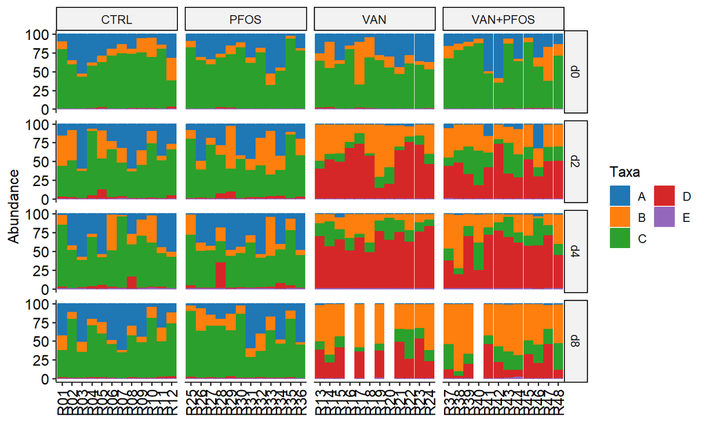

```r
#Melt data
dat <- suppressWarnings(psmelt(phy.top))
colnames(dat)[c(1,4)] <- c("Taxa","SampleID")

# Sort taxa
dat.sort <- sort_taxa(dat)

# rename taxa
levels(dat.sort$Taxa) <- LETTERS[seq(length(levels(dat.sort$Taxa)))]

# ensure that the variables are factors
dat.sort[,params$time_var] <- factor(dat.sort[,params$time_var])
dat.sort[,params$subject_var] <- factor(dat.sort[,params$subject_var])
dat.sort[,params$group_var] <- factor(dat.sort[,params$group_var])

# Create plot
p <- ggplot(dat.sort, aes(x = .data[[params$subject_var]],
                          y = Abundance,
                          fill = Taxa,
                          color = Taxa)) +
  geom_col() +
  xlab("") +
  facet_grid(get(params$time_var) ~ get(params$group_var),
             space = "free_x",scales = "free_x") +
  ggsci::scale_color_d3(palette = "category20") +
  ggsci::scale_fill_d3(palette = "category20") +
  guides(fill=guide_legend(ncol=2), color=guide_legend(ncol=2)) +
  theme_pubr(legend = "right") + rotate_x_text(angle = 90)
p
```

```r
# print tax table
# print tax table
tax <- dat.sort %>% distinct(Taxa, .keep_all = T)%>% select(Taxa, Kingdom, Phylum)


kable(tax,digits = 2,caption = paste("Taxa plotted", sep = " ")) %>%
  kable_classic(full_width = F, position = "left")
```

Taxa plotted

| Taxa | Kingdom | Phylum |
| --- | --- | --- |
| C | Bacteria | Firmicutes |
| B | Bacteria | Bacteroidetes |
| D | Bacteria | Proteobacteria |
| A | Bacteria | Actinobacteria |
| E | Others | Others |

```r
# clear the environment and release memory
rm(list = ls(all.names = TRUE))
invisible(gc())
```

## CLASS

### COUNTS

At class level the microbiome counts are as follows for each group and timepoint

```r
# load data
load("R_objects/Agglomerated.RData")
params <- readRDS( "R_objects/params_description")

# Remove samples with missing data
phy.use <- prune_samples(sample_names(phy.cl)[!is.na(sample_data(phy.cl)[,params$group_var]) & !is.na(sample_data(phy.cl)[,params$time_var])], phy.cl)

# Transform data
phy.rel <- transform_sample_counts(phy.use, fun = function(x) x/sum(x)*100)
dat <- psmelt(phy.rel)
# summarise per sample
sumsample <-
  dat %>%
  filter(Abundance > 0) %>%
  group_by(Sample, .data[[params$group_var]], .data[[params$time_var]]) %>%
  summarise(pct_0 = n(),
            pct_0.1 = sum(Abundance < 0.1),
            pct_0_1 = sum(Abundance >= 0.1 & Abundance < 1),
            pct_1_10 = sum(Abundance >= 1 & Abundance < 10),
            pct_10 = sum(Abundance > 10)) %>%
  pivot_longer(starts_with("pct"),
               names_to = c("Cutoff"),
               values_to = "Count") %>%
  group_by(Cutoff, .data[[params$group_var]], .data[[params$time_var]]) %>%
  summarise(mean = round(mean(Count),2),
            sd = round(sd(Count),2))
# summarise total
sumall <- dat %>%
  filter(Abundance > 0) %>%
  group_by(OTU, .data[[params$group_var]], .data[[params$time_var]]) %>%
  summarise(Abundance = mean(Abundance)) %>%
  group_by(.data[[params$group_var]], .data[[params$time_var]]) %>%
  summarise(pct_0 = n(),
            pct_0.1 = sum(Abundance < 0.1),
            pct_0_1 = sum(Abundance >= 0.1 & Abundance < 1),
            pct_1_10 = sum(Abundance >= 1 & Abundance < 10),
            pct_10 = sum(Abundance > 10)) %>%
  pivot_longer(starts_with("pct"),
               names_to = c("Cutoff"),
               values_to = "n")
# Combine
output <- full_join(sumall, sumsample) %>%
  pivot_wider(id_cols = c(Cutoff, .data[[params$time_var]]),
              names_from = .data[[params$group_var]],
              values_from = c(n, mean, sd),
              names_vary = "slowest") %>%
  mutate(Cutoff=factor(Cutoff))
levels(output$Cutoff) <- c("All", "n < 0.1%", "0.1% < n < 1.0%", "1.0% < n < 10%", "10%  < n")

# Create output table
kable(output, row.names = F,digits = 2, caption = 'Count of classes in general and per sample',align = "r") %>%
  kable_classic(full_width = F, position = "left")
```

Count of classes in general and per sample

| Cutoff | day | n_CTRL | mean_CTRL | sd_CTRL | n_PFOS | mean_PFOS | sd_PFOS | n_VAN | mean_VAN | sd_VAN | n_VAN+PFOS | mean_VAN+PFOS | sd_VAN+PFOS |
| --- | --- | --- | --- | --- | --- | --- | --- | --- | --- | --- | --- | --- | --- |
| All | d0 | 17 | 13.33 | 1.15 | 18 | 13.50 | 0.90 | 17 | 14.42 | 1.16 | 17 | 14.33 | 0.78 |
| n < 0.1% | d0 | 8 | 5.08 | 1.38 | 9 | 5.75 | 1.14 | 7 | 5.50 | 1.38 | 8 | 6.33 | 1.07 |
| 0.1% < n < 1.0% | d0 | 4 | 2.83 | 0.72 | 4 | 2.50 | 0.67 | 5 | 3.75 | 1.06 | 4 | 2.92 | 1.24 |
| 1.0% < n < 10% | d0 | 1 | 2.58 | 0.79 | 2 | 2.17 | 0.58 | 1 | 2.17 | 0.83 | 1 | 2.17 | 0.94 |
| 10% < n | d0 | 4 | 2.83 | 0.58 | 3 | 3.08 | 0.51 | 4 | 3.00 | 0.60 | 4 | 2.92 | 0.90 |
| All | d2 | 17 | 13.42 | 1.62 | 19 | 14.08 | 1.44 | 14 | 12.50 | 1.00 | 17 | 12.58 | 1.00 |
| n < 0.1% | d2 | 8 | 4.75 | 1.71 | 10 | 5.25 | 1.29 | 5 | 5.00 | 1.13 | 9 | 5.17 | 1.27 |
| 0.1% < n < 1.0% | d2 | 3 | 2.42 | 1.16 | 2 | 2.83 | 1.03 | 4 | 2.67 | 0.98 | 1 | 2.75 | 1.29 |
| 1.0% < n < 10% | d2 | 2 | 3.42 | 1.38 | 3 | 3.00 | 1.04 | 3 | 2.67 | 0.78 | 4 | 1.83 | 1.59 |
| 10% < n | d2 | 4 | 2.83 | 0.72 | 4 | 3.00 | 0.85 | 2 | 2.17 | 0.39 | 3 | 2.83 | 0.39 |
| All | d4 | 19 | 13.75 | 1.91 | 18 | 13.75 | 1.06 | 17 | 13.00 | 1.04 | 18 | 13.00 | 1.48 |
| n < 0.1% | d4 | 9 | 5.25 | 1.66 | 9 | 4.67 | 1.50 | 7 | 5.00 | 1.28 | 9 | 5.08 | 1.62 |
| 0.1% < n < 1.0% | d4 | 4 | 3.17 | 1.47 | 3 | 3.33 | 1.44 | 5 | 3.33 | 0.65 | 4 | 3.17 | 0.94 |
| 1.0% < n < 10% | d4 | 2 | 2.42 | 1.16 | 2 | 2.67 | 0.65 | 3 | 2.75 | 0.87 | 3 | 2.17 | 1.11 |
| 10% < n | d4 | 4 | 2.92 | 0.79 | 4 | 3.08 | 0.79 | 2 | 1.92 | 0.67 | 2 | 2.58 | 0.67 |
| All | d8 | 18 | 14.08 | 0.90 | 19 | 14.75 | 0.97 | 17 | 13.22 | 1.48 | 18 | 13.45 | 1.44 |
| n < 0.1% | d8 | 9 | 5.50 | 1.09 | 10 | 6.00 | 1.81 | 8 | 5.22 | 1.56 | 8 | 4.55 | 1.51 |
| 0.1% < n < 1.0% | d8 | 3 | 2.58 | 0.90 | 3 | 3.42 | 1.24 | 4 | 3.00 | 1.58 | 5 | 3.45 | 0.52 |
| 1.0% < n < 10% | d8 | 2 | 3.08 | 0.90 | 2 | 2.50 | 0.80 | 3 | 2.67 | 1.00 | 3 | 3.18 | 1.25 |
| 10% < n | d8 | 4 | 2.92 | 0.51 | 4 | 2.83 | 0.72 | 2 | 2.33 | 0.50 | 2 | 2.27 | 0.79 |

### PLOTS

To improve the interpretation of the compositional plots I will pretreat the data with three steps:

1. Filter taxa by average abundance (minimum 1 %) and rank (max 19 features + “Others”)
2. Sort the plotted taxa by full phylogeny
3. Change taxa names in plot to a letter and include table of full taxonomy

Following this I will incorporate both time_var and subject_var in the plot

```r
# Filter by abundance, then rank
phy.top <- filter_abundance(phy.rel, group = params$group_var,includes = "any") %>% filter_rank(group = params$time_var,min.rank = 6,includes = "any")
```

```
## 18 features grouped as 'Others' in the output
```

```
## 1 features grouped as 'Others' in the output
```

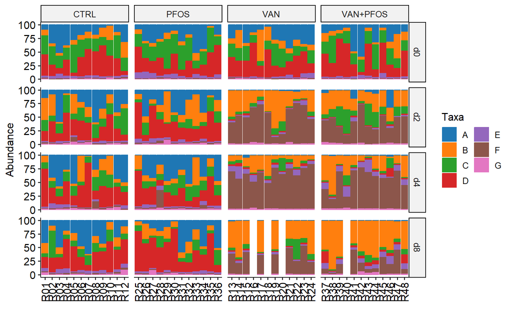

```r
#Melt data
dat <- suppressWarnings(psmelt(phy.top))
colnames(dat)[c(1,4)] <- c("Taxa","SampleID")

# Sort taxa
dat.sort <- sort_taxa(dat)

# rename taxa
levels(dat.sort$Taxa) <- LETTERS[seq(length(levels(dat.sort$Taxa)))]

# ensure that the variables are factors
dat.sort[,params$time_var] <- factor(dat.sort[,params$time_var])
dat.sort[,params$subject_var] <- factor(dat.sort[,params$subject_var])
dat.sort[,params$group_var] <- factor(dat.sort[,params$group_var])

# Create plot
p <- ggplot(dat.sort, aes(x = .data[[params$subject_var]],
                          y = Abundance,
                          fill = Taxa,
                          color = Taxa)) +
  geom_col() +
  xlab("") +
  facet_grid(get(params$time_var) ~ get(params$group_var),
             space = "free_x",scales = "free_x") +
  ggsci::scale_color_d3(palette = "category20") +
  ggsci::scale_fill_d3(palette = "category20") +
  guides(fill=guide_legend(ncol=2), color=guide_legend(ncol=2)) +
  theme_pubr(legend = "right") + rotate_x_text(angle = 90)
p
```

```r
# print tax table
# print tax table
tax <- dat.sort %>% distinct(Taxa,.keep_all = T) %>% select(Taxa, Kingdom, Phylum, Class)

kable(tax,digits = 2,caption = paste("Taxa plotted", sep = " ")) %>%
  kable_classic(full_width = F, position = "left")
```

Taxa plotted

| Taxa | Kingdom | Phylum | Class |
| --- | --- | --- | --- |
| B | Bacteria | Bacteroidetes | Bacteroidia |
| F | Bacteria | Proteobacteria | Gammaproteobacteria |
| D | Bacteria | Firmicutes | Clostridia |
| A | Bacteria | Actinobacteria | Actinobacteria |
| C | Bacteria | Firmicutes | Bacilli |
| E | Bacteria | Firmicutes | Erysipelotrichia |
| G | Others | Others | Others |

```r
# clear the environment and release memory
rm(list = ls(all.names = TRUE))
invisible(gc())
```

## ORDER

### COUNTS

At order level the microbiome counts are as follows for each group and timepoint

```r
# load data
load("R_objects/Agglomerated.RData")
params <- readRDS( "R_objects/params_description")

# Remove samples with missing data
phy.use <- prune_samples(sample_names(phy.or)[!is.na(sample_data(phy.or)[,params$group_var]) & !is.na(sample_data(phy.or)[,params$time_var])], phy.or)


# Transform data
phy.rel <- transform_sample_counts(phy.use, fun = function(x) x/sum(x)*100)
dat <- psmelt(phy.rel)
# summarise per sample
sumsample <-
  dat %>%
  filter(Abundance > 0) %>%
  group_by(Sample, .data[[params$group_var]], .data[[params$time_var]]) %>%
  summarise(pct_0 = n(),
            pct_0.1 = sum(Abundance < 0.1),
            pct_0_1 = sum(Abundance >= 0.1 & Abundance < 1),
            pct_1_10 = sum(Abundance >= 1 & Abundance < 10),
            pct_10 = sum(Abundance > 10)) %>%
  pivot_longer(starts_with("pct"),
               names_to = c("Cutoff"),
               values_to = "Count") %>%
  group_by(Cutoff, .data[[params$group_var]], .data[[params$time_var]]) %>%
  summarise(mean = round(mean(Count),2),
            sd = round(sd(Count),2))
# summarise total
sumall <- dat %>%
  filter(Abundance > 0) %>%
  group_by(OTU, .data[[params$group_var]], .data[[params$time_var]]) %>%
  summarise(Abundance = mean(Abundance)) %>%
  group_by(.data[[params$group_var]], .data[[params$time_var]]) %>%
  summarise(pct_0 = n(),
            pct_0.1 = sum(Abundance < 0.1),
            pct_0_1 = sum(Abundance >= 0.1 & Abundance < 1),
            pct_1_10 = sum(Abundance >= 1 & Abundance < 10),
            pct_10 = sum(Abundance > 10)) %>%
  pivot_longer(starts_with("pct"),
               names_to = c("Cutoff"),
               values_to = "n")
# Combine
output <- full_join(sumall, sumsample) %>%
  pivot_wider(id_cols = c(Cutoff, .data[[params$time_var]]),
              names_from = .data[[params$group_var]],
              values_from = c(n, mean, sd),
              names_vary = "slowest") %>%
  mutate(Cutoff=factor(Cutoff))
levels(output$Cutoff) <- c("All", "n < 0.1%", "0.1% < n < 1.0%", "1.0% < n < 10%", "10%  < n")

# Create output table
kable(output, row.names = F,digits = 2, caption = 'Count of orders in general and per sample',align = "r") %>%
  kable_classic(full_width = F, position = "left")
```

Count of orders in general and per sample

| Cutoff | day | n_CTRL | mean_CTRL | sd_CTRL | n_PFOS | mean_PFOS | sd_PFOS | n_VAN | mean_VAN | sd_VAN | n_VAN+PFOS | mean_VAN+PFOS | sd_VAN+PFOS |
| --- | --- | --- | --- | --- | --- | --- | --- | --- | --- | --- | --- | --- | --- |
| All | d0 | 23 | 18.17 | 1.34 | 25 | 18.42 | 1.16 | 26 | 20.08 | 1.44 | 25 | 19.33 | 1.07 |
| n < 0.1% | d0 | 13 | 9.17 | 1.80 | 15 | 9.92 | 1.51 | 15 | 10.42 | 1.24 | 15 | 10.67 | 1.97 |
| 0.1% < n < 1.0% | d0 | 5 | 3.58 | 1.31 | 5 | 3.25 | 0.97 | 6 | 4.58 | 1.08 | 5 | 3.50 | 1.68 |
| 1.0% < n < 10% | d0 | 1 | 2.58 | 0.79 | 2 | 2.17 | 0.58 | 1 | 2.08 | 0.79 | 1 | 2.25 | 1.06 |
| 10% < n | d0 | 4 | 2.83 | 0.58 | 3 | 3.08 | 0.51 | 4 | 3.00 | 0.60 | 4 | 2.92 | 0.90 |
| All | d2 | 25 | 18.33 | 1.50 | 27 | 18.67 | 1.50 | 21 | 16.17 | 1.59 | 24 | 16.33 | 1.92 |
| n < 0.1% | d2 | 15 | 9.00 | 1.76 | 17 | 8.75 | 1.48 | 12 | 8.58 | 1.68 | 16 | 8.75 | 2.05 |
| 0.1% < n < 1.0% | d2 | 4 | 3.00 | 1.48 | 3 | 3.75 | 1.06 | 4 | 2.83 | 1.19 | 2 | 3.00 | 1.28 |
| 1.0% < n < 10% | d2 | 2 | 3.50 | 1.31 | 3 | 3.17 | 1.19 | 3 | 2.58 | 0.90 | 3 | 1.75 | 1.60 |
| 10% < n | d2 | 4 | 2.83 | 0.72 | 4 | 3.00 | 0.85 | 2 | 2.17 | 0.39 | 3 | 2.83 | 0.39 |
| All | d4 | 27 | 18.92 | 2.23 | 26 | 19.00 | 1.04 | 23 | 15.75 | 1.48 | 24 | 16.25 | 2.42 |
| n < 0.1% | d4 | 16 | 9.42 | 2.11 | 15 | 8.83 | 1.95 | 13 | 7.67 | 1.83 | 14 | 7.75 | 2.45 |
| 0.1% < n < 1.0% | d4 | 5 | 4.00 | 1.28 | 5 | 4.33 | 1.92 | 5 | 3.42 | 0.67 | 5 | 3.75 | 1.06 |
| 1.0% < n < 10% | d4 | 2 | 2.58 | 1.08 | 2 | 2.75 | 0.75 | 3 | 2.75 | 0.87 | 3 | 2.17 | 1.11 |
| 10% < n | d4 | 4 | 2.92 | 0.79 | 4 | 3.08 | 0.79 | 2 | 1.92 | 0.67 | 2 | 2.58 | 0.67 |
| All | d8 | 25 | 19.33 | 0.65 | 27 | 20.00 | 0.74 | 24 | 17.11 | 1.90 | 27 | 17.73 | 2.00 |
| n < 0.1% | d8 | 15 | 10.17 | 1.19 | 17 | 10.25 | 1.66 | 15 | 8.89 | 1.36 | 17 | 8.73 | 1.79 |
| 0.1% < n < 1.0% | d8 | 4 | 3.17 | 1.11 | 4 | 4.42 | 1.16 | 4 | 3.33 | 1.80 | 5 | 3.55 | 0.93 |
| 1.0% < n < 10% | d8 | 2 | 3.08 | 0.90 | 2 | 2.50 | 0.80 | 3 | 2.56 | 0.88 | 3 | 3.18 | 1.25 |
| 10% < n | d8 | 4 | 2.92 | 0.51 | 4 | 2.83 | 0.72 | 2 | 2.33 | 0.50 | 2 | 2.27 | 0.79 |

### PLOTS

To improve the interpretation of the compositional plots I will pretreat the data with three steps:

1. Filter taxa by average abundance (minimum 1 %) and rank (max 19 features + “Others”)
2. Sort the plotted taxa by full phylogeny
3. Change taxa names in plot to a letter and include table of full taxonomy

Following this I will incorporate both time_var and subject_var in the plot

```r
# Filter by abundance, then rank
phy.top <- filter_abundance(phy.rel, group = params$group_var,includes = "any") %>% filter_rank(group = params$time_var,min.rank = 6,includes = "any")
```

```
## 36 features grouped as 'Others' in the output
```

```
## 1 features grouped as 'Others' in the output
```

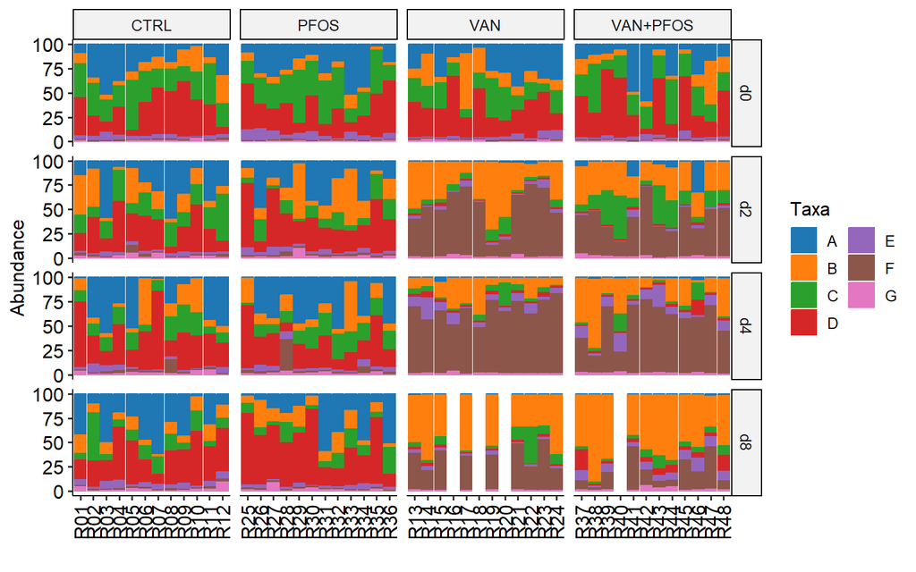

```r
#Melt data
dat <- suppressWarnings(psmelt(phy.top))
colnames(dat)[c(1,4)] <- c("Taxa","SampleID")

# Sort taxa
dat.sort <- sort_taxa(dat)

# rename taxa
levels(dat.sort$Taxa) <- LETTERS[seq(length(levels(dat.sort$Taxa)))]

# ensure that the variables are factors
dat.sort[,params$time_var] <- factor(dat.sort[,params$time_var])
dat.sort[,params$subject_var] <- factor(dat.sort[,params$subject_var])
dat.sort[,params$group_var] <- factor(dat.sort[,params$group_var])

# Create plot
p <- ggplot(dat.sort, aes(x = .data[[params$subject_var]],
                          y = Abundance,
                          fill = Taxa,
                          color = Taxa)) +
  geom_col() +
  xlab("") +
  facet_grid(get(params$time_var) ~ get(params$group_var),
             space = "free_x",scales = "free_x") +
  ggsci::scale_color_d3(palette = "category20") +
  ggsci::scale_fill_d3(palette = "category20") +
  guides(fill=guide_legend(ncol=2), color=guide_legend(ncol=2)) +
  theme_pubr(legend = "right") + rotate_x_text(angle = 90)
p
```

```r
# print tax table
# print tax table
tax <- dat.sort %>% distinct(Taxa,.keep_all = T) %>% select(Taxa, Kingdom, Phylum, Class, Order)

kable(tax,digits = 2,caption = paste("Taxa plotted", sep = " ")) %>%
  kable_classic(full_width = F, position = "left")
```

Taxa plotted

| Taxa | Kingdom | Phylum | Class | Order |
| --- | --- | --- | --- | --- |
| B | Bacteria | Bacteroidetes | Bacteroidia | Bacteroidales |
| F | Bacteria | Proteobacteria | Gammaproteobacteria | Enterobacterales |
| D | Bacteria | Firmicutes | Clostridia | Clostridiales |
| A | Bacteria | Actinobacteria | Actinobacteria | Bifidobacteriales |
| C | Bacteria | Firmicutes | Bacilli | Lactobacillales |
| E | Bacteria | Firmicutes | Erysipelotrichia | Erysipelotrichales |
| G | Others | Others | Others | Others |

```r
# clear the environment and release memory
rm(list = ls(all.names = TRUE))
invisible(gc())
```

## FAMILY

### COUNTS

At family level the microbiome counts are as follows for each group and timepoint

```r
# load data
load("R_objects/Agglomerated.RData")
params <- readRDS( "R_objects/params_description")

# Remove samples with missing data
phy.use <- prune_samples(sample_names(phy.fa)[!is.na(sample_data(phy.fa)[,params$group_var]) & !is.na(sample_data(phy.fa)[,params$time_var])], phy.fa)

# Transform data
phy.rel <- transform_sample_counts(phy.use, fun = function(x) x/sum(x)*100)
dat <- psmelt(phy.rel)
# summarise per sample
sumsample <-
  dat %>%
  filter(Abundance > 0) %>%
  group_by(Sample, .data[[params$group_var]], .data[[params$time_var]]) %>%
  summarise(pct_0 = n(),
            pct_0.1 = sum(Abundance < 0.1),
            pct_0_1 = sum(Abundance >= 0.1 & Abundance < 1),
            pct_1_10 = sum(Abundance >= 1 & Abundance < 10),
            pct_10 = sum(Abundance > 10)) %>%
  pivot_longer(starts_with("pct"),
               names_to = c("Cutoff"),
               values_to = "Count") %>%
  group_by(Cutoff, .data[[params$group_var]], .data[[params$time_var]]) %>%
  summarise(mean = round(mean(Count),2),
            sd = round(sd(Count),2))
# summarise total
sumall <- dat %>%
  filter(Abundance > 0) %>%
  group_by(OTU, .data[[params$group_var]], .data[[params$time_var]]) %>%
  summarise(Abundance = mean(Abundance)) %>%
  group_by(.data[[params$group_var]], .data[[params$time_var]]) %>%
  summarise(pct_0 = n(),
            pct_0.1 = sum(Abundance < 0.1),
            pct_0_1 = sum(Abundance >= 0.1 & Abundance < 1),
            pct_1_10 = sum(Abundance >= 1 & Abundance < 10),
            pct_10 = sum(Abundance > 10)) %>%
  pivot_longer(starts_with("pct"),
               names_to = c("Cutoff"),
               values_to = "n")
# Combine
output <- full_join(sumall, sumsample) %>%
  pivot_wider(id_cols = c(Cutoff, .data[[params$time_var]]),
              names_from = .data[[params$group_var]],
              values_from = c(n, mean, sd),
              names_vary = "slowest") %>%
  mutate(Cutoff=factor(Cutoff))
levels(output$Cutoff) <- c("All", "n < 0.1%", "0.1% < n < 1.0%", "1.0% < n < 10%", "10%  < n")

# Create output table
kable(output, row.names = F,digits = 2, caption = 'Count of families in general and per sample',align = "r") %>%
  kable_classic(full_width = F, position = "left")
```

Count of families in general and per sample

| Cutoff | day | n_CTRL | mean_CTRL | sd_CTRL | n_PFOS | mean_PFOS | sd_PFOS | n_VAN | mean_VAN | sd_VAN | n_VAN+PFOS | mean_VAN+PFOS | sd_VAN+PFOS |
| --- | --- | --- | --- | --- | --- | --- | --- | --- | --- | --- | --- | --- | --- |
| All | d0 | 44 | 34.17 | 2.33 | 47 | 34.58 | 2.11 | 50 | 37.00 | 2.00 | 47 | 36.42 | 2.35 |
| n < 0.1% | d0 | 23 | 16.42 | 3.00 | 27 | 17.67 | 3.17 | 27 | 17.92 | 1.88 | 26 | 19.17 | 2.82 |
| 0.1% < n < 1.0% | d0 | 13 | 8.83 | 2.08 | 10 | 7.75 | 2.42 | 14 | 10.08 | 1.38 | 12 | 8.58 | 1.73 |
| 1.0% < n < 10% | d0 | 4 | 5.67 | 1.37 | 7 | 6.00 | 1.81 | 5 | 5.50 | 1.31 | 5 | 5.58 | 1.08 |
| 10% < n | d0 | 4 | 3.25 | 0.97 | 3 | 3.17 | 0.83 | 4 | 3.50 | 0.80 | 4 | 3.08 | 0.67 |
| All | d2 | 46 | 33.58 | 1.83 | 48 | 33.33 | 2.15 | 40 | 27.92 | 3.65 | 44 | 28.17 | 3.27 |
| n < 0.1% | d2 | 26 | 15.50 | 2.78 | 26 | 14.67 | 2.19 | 25 | 17.50 | 3.09 | 30 | 17.75 | 3.41 |
| 0.1% < n < 1.0% | d2 | 9 | 8.42 | 2.11 | 11 | 8.17 | 2.44 | 9 | 5.42 | 2.84 | 8 | 5.67 | 2.53 |
| 1.0% < n < 10% | d2 | 8 | 6.75 | 1.71 | 6 | 7.58 | 2.19 | 4 | 2.83 | 0.94 | 3 | 1.92 | 1.31 |
| 10% < n | d2 | 3 | 2.92 | 1.00 | 5 | 2.92 | 1.24 | 2 | 2.17 | 0.39 | 3 | 2.83 | 0.39 |
| All | d4 | 48 | 33.75 | 2.09 | 45 | 34.42 | 1.24 | 43 | 26.58 | 2.27 | 42 | 27.33 | 4.19 |
| n < 0.1% | d4 | 24 | 15.58 | 2.81 | 23 | 15.58 | 2.39 | 27 | 15.67 | 3.06 | 23 | 15.67 | 3.39 |
| 0.1% < n < 1.0% | d4 | 14 | 9.42 | 1.62 | 12 | 9.33 | 2.64 | 11 | 5.83 | 1.40 | 14 | 7.00 | 2.13 |
| 1.0% < n < 10% | d4 | 6 | 5.58 | 1.98 | 7 | 6.58 | 1.44 | 3 | 3.25 | 1.36 | 3 | 2.08 | 1.31 |
| 10% < n | d4 | 4 | 3.17 | 0.58 | 3 | 2.92 | 0.79 | 2 | 1.83 | 0.72 | 2 | 2.58 | 0.67 |
| All | d8 | 50 | 36.58 | 2.15 | 52 | 36.17 | 1.34 | 48 | 29.89 | 3.76 | 50 | 31.27 | 4.13 |
| n < 0.1% | d8 | 29 | 18.33 | 2.87 | 30 | 17.33 | 1.97 | 31 | 16.22 | 2.54 | 33 | 17.09 | 3.81 |
| 0.1% < n < 1.0% | d8 | 10 | 7.83 | 2.21 | 11 | 9.08 | 1.68 | 11 | 8.00 | 2.69 | 8 | 6.82 | 2.23 |
| 1.0% < n < 10% | d8 | 7 | 7.67 | 1.92 | 7 | 6.75 | 1.66 | 4 | 3.44 | 1.74 | 7 | 5.09 | 1.64 |
| 10% < n | d8 | 4 | 2.75 | 0.87 | 4 | 3.00 | 0.85 | 2 | 2.22 | 0.44 | 2 | 2.27 | 0.79 |

### PLOTS

To improve the interpretation of the compositional plots I will pretreat the data with three steps:

1. Filter taxa by average abundance (minimum 1 %) and rank (max 19 features + “Others”)
2. Sort the plotted taxa by full phylogeny
3. Change taxa names in plot to a letter and include table of full taxonomy

Following this I will incorporate both time_var and subject_var in the plot

```r
# Filter by abundance, then rank
phy.top <- filter_abundance(phy.rel, group = params$group_var,includes = "any") %>% filter_rank(group = params$time_var, min.rank = 6, includes = "any")
```

```
## 70 features grouped as 'Others' in the output
```

```
## 2 features grouped as 'Others' in the output
```

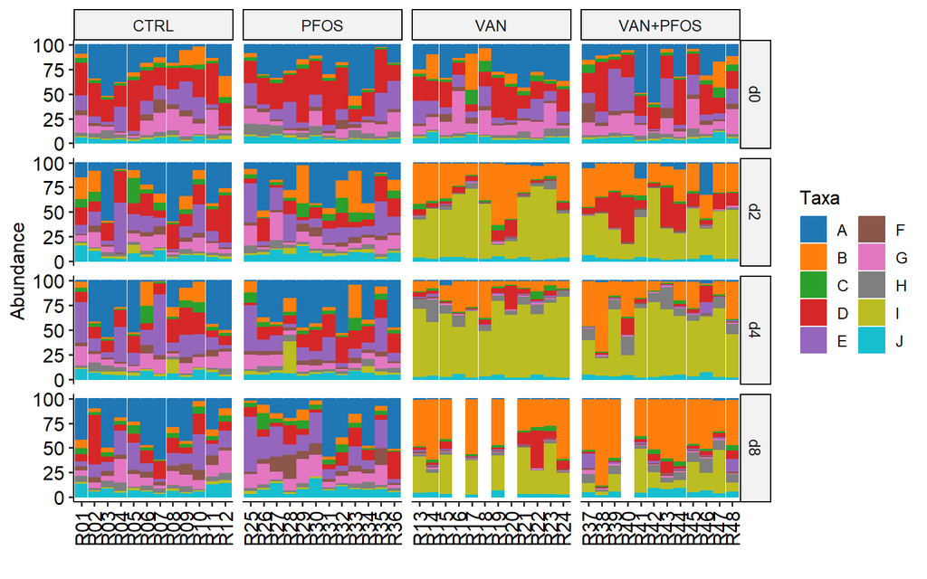

```r
#Melt data
dat <- suppressWarnings(psmelt(phy.top))
colnames(dat)[c(1,4)] <- c("Taxa","SampleID")

# Sort taxa
dat.sort <- sort_taxa(dat)

# rename taxa
levels(dat.sort$Taxa) <- LETTERS[seq(length(levels(dat.sort$Taxa)))]

# ensure that the variables are factors
dat.sort[,params$time_var] <- factor(dat.sort[,params$time_var])
dat.sort[,params$subject_var] <- factor(dat.sort[,params$subject_var])
dat.sort[,params$group_var] <- factor(dat.sort[,params$group_var])

# Create plot
p <- ggplot(dat.sort, aes(x = .data[[params$subject_var]],
                          y = Abundance,
                          fill = Taxa,
                          color = Taxa)) +
  geom_col() +
  xlab("") +
  facet_grid(get(params$time_var) ~ get(params$group_var),
             space = "free_x",scales = "free_x") +
  ggsci::scale_color_d3(palette = "category20") +
  ggsci::scale_fill_d3(palette = "category20") +
  guides(fill=guide_legend(ncol=2), color=guide_legend(ncol=2)) +
  theme_pubr(legend = "right") + rotate_x_text(angle = 90)
p
```

```r
# print tax table
# print tax table
tax <- dat.sort %>% distinct(Taxa,.keep_all = T) %>% select(Taxa, Kingdom, Phylum, Class, Order,Family)

kable(tax,digits = 2,caption = paste("Taxa plotted", sep = " ")) %>%
  kable_classic(full_width = F, position = "left")
```

Taxa plotted

| Taxa | Kingdom | Phylum | Class | Order | Family |
| --- | --- | --- | --- | --- | --- |
| B | Bacteria | Bacteroidetes | Bacteroidia | Bacteroidales | Bacteroidaceae |
| I | Bacteria | Proteobacteria | Gammaproteobacteria | Enterobacterales | Enterobacteriaceae |
| E | Bacteria | Firmicutes | Clostridia | Clostridiales | Lachnospiraceae |
| A | Bacteria | Actinobacteria | Actinobacteria | Bifidobacteriales | Bifidobacteriaceae |
| D | Bacteria | Firmicutes | Bacilli | Lactobacillales | Lactobacillaceae |
| G | Bacteria | Firmicutes | Clostridia | Clostridiales | Ruminococcaceae |
| C | Bacteria | Bacteroidetes | Bacteroidia | Bacteroidales | Prevotellaceae |
| F | Bacteria | Firmicutes | Clostridia | Clostridiales | Order_Clostridiales |
| H | Bacteria | Firmicutes | Erysipelotrichia | Erysipelotrichales | Erysipelotrichaceae |
| J | Others | Others | Others | Others | Others |

```r
# clear the environment and release memory
rm(list = ls(all.names = TRUE))
invisible(gc())
```

## GENUS

### COUNTS

At genus level the microbiome counts are as follows for each group and timepoint

```r
# load data
load("R_objects/Agglomerated.RData")
params <- readRDS( "R_objects/params_description")

# Remove samples with missing data
phy.use <- prune_samples(sample_names(phy.ge)[!is.na(sample_data(phy.ge)[,params$group_var]) & !is.na(sample_data(phy.ge)[,params$time_var])], phy.ge)

# Transform data
phy.rel <- transform_sample_counts(phy.use, fun = function(x) x/sum(x)*100)
dat <- psmelt(phy.rel)
# summarise per sample
sumsample <-
  dat %>%
  filter(Abundance > 0) %>%
  group_by(Sample, .data[[params$group_var]], .data[[params$time_var]]) %>%
  summarise(pct_0 = n(),
            pct_0.1 = sum(Abundance < 0.1),
            pct_0_1 = sum(Abundance >= 0.1 & Abundance < 1),
            pct_1_10 = sum(Abundance >= 1 & Abundance < 10),
            pct_10 = sum(Abundance > 10)) %>%
  pivot_longer(starts_with("pct"),
               names_to = c("Cutoff"),
               values_to = "Count") %>%
  group_by(Cutoff, .data[[params$group_var]], .data[[params$time_var]]) %>%
  summarise(mean = round(mean(Count),2),
            sd = round(sd(Count),2))
# summarise total
sumall <- dat %>%
  filter(Abundance > 0) %>%
  group_by(OTU, .data[[params$group_var]], .data[[params$time_var]]) %>%
  summarise(Abundance = mean(Abundance)) %>%
  group_by(.data[[params$group_var]], .data[[params$time_var]]) %>%
  summarise(pct_0 = n(),
            pct_0.1 = sum(Abundance < 0.1),
            pct_0_1 = sum(Abundance >= 0.1 & Abundance < 1),
            pct_1_10 = sum(Abundance >= 1 & Abundance < 10),
            pct_10 = sum(Abundance > 10)) %>%
  pivot_longer(starts_with("pct"),
               names_to = c("Cutoff"),
               values_to = "n")
# Combine
output <- full_join(sumall, sumsample) %>%
  pivot_wider(id_cols = c(Cutoff, .data[[params$time_var]]),
              names_from = .data[[params$group_var]],
              values_from = c(n, mean, sd),
              names_vary = "slowest") %>%
  mutate(Cutoff=factor(Cutoff))
levels(output$Cutoff) <- c("All", "n < 0.1%", "0.1% < n < 1.0%", "1.0% < n < 10%", "10%  < n")

# Create output table
kable(output, row.names = F,digits = 2, caption = 'Count of genera in general and per sample',align = "r") %>%
  kable_classic(full_width = F, position = "left")
```

Count of genera in general and per sample

| Cutoff | day | n_CTRL | mean_CTRL | sd_CTRL | n_PFOS | mean_PFOS | sd_PFOS | n_VAN | mean_VAN | sd_VAN | n_VAN+PFOS | mean_VAN+PFOS | sd_VAN+PFOS |
| --- | --- | --- | --- | --- | --- | --- | --- | --- | --- | --- | --- | --- | --- |
| All | d0 | 104 | 73.83 | 4.99 | 108 | 74.17 | 5.41 | 109 | 78.25 | 3.55 | 109 | 76.42 | 6.72 |
| n < 0.1% | d0 | 64 | 45.67 | 3.85 | 75 | 48.50 | 5.85 | 67 | 46.75 | 3.39 | 65 | 46.83 | 5.98 |
| 0.1% < n < 1.0% | d0 | 29 | 17.42 | 4.68 | 20 | 15.50 | 3.68 | 31 | 20.67 | 3.03 | 33 | 18.67 | 4.12 |
| 1.0% < n < 10% | d0 | 8 | 7.58 | 2.11 | 10 | 7.00 | 1.95 | 7 | 7.92 | 1.16 | 6 | 8.08 | 2.84 |
| 10% < n | d0 | 3 | 3.17 | 1.03 | 3 | 3.17 | 0.94 | 4 | 2.92 | 0.90 | 5 | 2.83 | 0.72 |
| All | d2 | 100 | 72.42 | 5.58 | 106 | 72.58 | 6.23 | 86 | 44.17 | 8.73 | 87 | 45.83 | 5.94 |
| n < 0.1% | d2 | 63 | 43.17 | 4.55 | 61 | 40.17 | 5.72 | 65 | 31.83 | 6.01 | 70 | 33.50 | 6.05 |
| 0.1% < n < 1.0% | d2 | 22 | 17.67 | 3.26 | 30 | 20.17 | 4.63 | 15 | 7.25 | 4.75 | 12 | 7.33 | 3.11 |
| 1.0% < n < 10% | d2 | 13 | 8.83 | 2.72 | 12 | 9.42 | 2.19 | 4 | 2.92 | 1.08 | 2 | 2.17 | 1.80 |
| 10% < n | d2 | 2 | 2.75 | 0.87 | 3 | 2.83 | 1.27 | 2 | 2.17 | 0.39 | 3 | 2.83 | 0.39 |
| All | d4 | 106 | 71.17 | 3.43 | 99 | 74.58 | 3.80 | 81 | 37.17 | 3.24 | 81 | 39.83 | 9.91 |
| n < 0.1% | d4 | 61 | 39.33 | 4.60 | 60 | 44.42 | 6.32 | 63 | 24.50 | 3.29 | 55 | 26.08 | 5.92 |
| 0.1% < n < 1.0% | d4 | 30 | 20.00 | 3.95 | 26 | 19.08 | 3.34 | 12 | 7.17 | 2.25 | 19 | 8.58 | 4.25 |
| 1.0% < n < 10% | d4 | 13 | 9.42 | 3.06 | 10 | 8.58 | 1.88 | 4 | 3.75 | 1.76 | 5 | 2.92 | 1.38 |
| 10% < n | d4 | 2 | 2.42 | 1.00 | 3 | 2.50 | 0.80 | 2 | 1.75 | 0.62 | 2 | 2.25 | 0.62 |
| All | d8 | 112 | 77.33 | 5.60 | 111 | 75.67 | 5.18 | 92 | 47.11 | 6.88 | 97 | 48.82 | 8.42 |
| n < 0.1% | d8 | 73 | 47.25 | 5.26 | 70 | 43.92 | 5.85 | 71 | 30.33 | 5.34 | 75 | 31.73 | 7.32 |
| 0.1% < n < 1.0% | d8 | 25 | 17.83 | 1.70 | 27 | 20.42 | 3.00 | 14 | 10.89 | 3.52 | 13 | 9.27 | 3.13 |
| 1.0% < n < 10% | d8 | 11 | 9.75 | 3.05 | 12 | 8.83 | 1.47 | 5 | 3.67 | 1.66 | 7 | 5.73 | 1.49 |
| 10% < n | d8 | 3 | 2.50 | 0.90 | 2 | 2.50 | 1.09 | 2 | 2.22 | 0.44 | 2 | 2.09 | 0.70 |

### PLOTS

To improve the interpretation of the compositional plots I will pretreat the data with three steps:

1. Filter taxa by average abundance (minimum 1 %) and rank (max 19 features + “Others”)
2. Sort the plotted taxa by full phylogeny
3. Change taxa names in plot to a letter and include table of full taxonomy

Following this I will incorporate both time_var and subject_var in the plot

```r
# Filter by abundance, then rank
phy.top <- filter_abundance(phy.rel, group = params$group_var,includes = "any") %>% filter_rank(group = params$time_var, min.rank = 6, includes = "any")
```

```
## 157 features grouped as 'Others' in the output
```

```
## 9 features grouped as 'Others' in the output
```

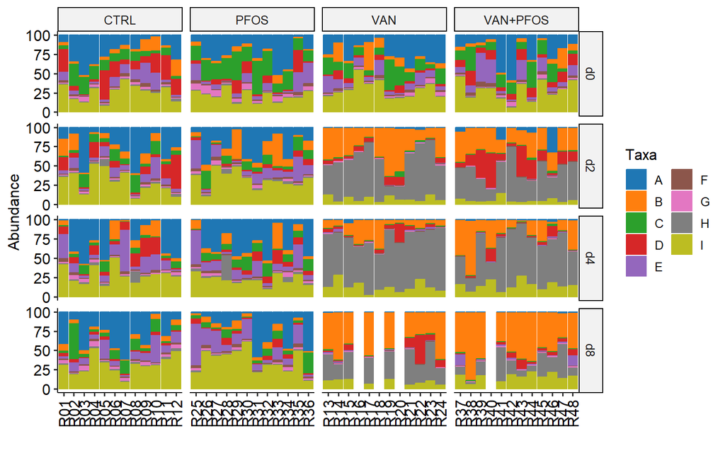

```r
#Melt data
dat <- suppressWarnings(psmelt(phy.top))
colnames(dat)[c(1,4)] <- c("Taxa","SampleID")

# Sort taxa
dat.sort <- sort_taxa(dat)

# rename taxa
levels(dat.sort$Taxa) <- LETTERS[seq(length(levels(dat.sort$Taxa)))]

# ensure that the variables are factors
dat.sort[,params$time_var] <- factor(dat.sort[,params$time_var])
dat.sort[,params$subject_var] <- factor(dat.sort[,params$subject_var])
dat.sort[,params$group_var] <- factor(dat.sort[,params$group_var])

# Create plot
p <- ggplot(dat.sort, aes(x = .data[[params$subject_var]],
                          y = Abundance,
                          fill = Taxa,
                          color = Taxa)) +
  geom_col() +
  xlab("") +
  facet_grid(get(params$time_var) ~ get(params$group_var),
             space = "free_x",scales = "free_x") +
  ggsci::scale_color_d3(palette = "category20") +
  ggsci::scale_fill_d3(palette = "category20") +
  guides(fill=guide_legend(ncol=2), color=guide_legend(ncol=2)) +
  theme_pubr(legend = "right") + rotate_x_text(angle = 90)
p
```

```r
suppressMessages(ggsave(filename = "plots/relabu/relative_abundance_plot_all_genus.png", plot = p, device = "png", dpi = 300, units = "mm", height = 200, width = 300))
suppressMessages(ggsave(filename = "plots/relabu/relative_abundance_plot_all_genus.pdf", plot = p, device = "pdf", dpi = 300, units = "mm", height = 200, width = 300))
# print tax table
# print tax table
tax <- dat.sort %>% distinct(Taxa,.keep_all = T) %>% select(Taxa, Kingdom, Phylum, Class, Order,Family,Genus)

try(kable(tax,digits = 2,caption = paste("Taxa plotted", sep = " ")) %>%
  kable_classic(full_width = F, position = "left") %>%
  save_kable(file = "plots/relabu/relative_abundance_plot_all_genus_complist.pdf"))
```

```
## PhantomJS not found. You can install it with webshot::install_phantomjs(). If it is installed, please make sure the phantomjs executable can be found via the PATH variable.
```

```
## save_kable could not create image with webshot package. Please check for any webshot messages
```

```r
# clear the environment and release memory
rm(list = ls(all.names = TRUE))
invisible(gc())
```

## SPECIES

### COUNTS

At species level the microbiome counts are as follows for each group and timepoint

```r
# load data
load("R_objects/Agglomerated.RData")
params <- readRDS( "R_objects/params_description")

# Remove samples with missing data
phy.use <- prune_samples(sample_names(phy.sp)[!is.na(sample_data(phy.sp)[,params$group_var]) & !is.na(sample_data(phy.sp)[,params$time_var])], phy.sp)

# Transform data
phy.rel <- transform_sample_counts(phy.use, fun = function(x) x/sum(x)*100)
dat <- psmelt(phy.rel)
# summarise per sample
sumsample <-
  dat %>%
  filter(Abundance > 0) %>%
  group_by(Sample, .data[[params$group_var]], .data[[params$time_var]]) %>%
  summarise(pct_0 = n(),
            pct_0.1 = sum(Abundance < 0.1),
            pct_0_1 = sum(Abundance >= 0.1 & Abundance < 1),
            pct_1_10 = sum(Abundance >= 1 & Abundance < 10),
            pct_10 = sum(Abundance > 10)) %>%
  pivot_longer(starts_with("pct"),
               names_to = c("Cutoff"),
               values_to = "Count") %>%
  group_by(Cutoff, .data[[params$group_var]], .data[[params$time_var]]) %>%
  summarise(mean = round(mean(Count),2),
            sd = round(sd(Count),2))
# summarise total
sumall <- dat %>%
  filter(Abundance > 0) %>%
  group_by(OTU, .data[[params$group_var]], .data[[params$time_var]]) %>%
  summarise(Abundance = mean(Abundance)) %>%
  group_by(.data[[params$group_var]], .data[[params$time_var]]) %>%
  summarise(pct_0 = n(),
            pct_0.1 = sum(Abundance < 0.1),
            pct_0_1 = sum(Abundance >= 0.1 & Abundance < 1),
            pct_1_10 = sum(Abundance >= 1 & Abundance < 10),
            pct_10 = sum(Abundance > 10)) %>%
  pivot_longer(starts_with("pct"),
               names_to = c("Cutoff"),
               values_to = "n")
# Combine
output <- full_join(sumall, sumsample) %>%
  pivot_wider(id_cols = c(Cutoff, .data[[params$time_var]]),
              names_from = .data[[params$group_var]],
              values_from = c(n, mean, sd),
              names_vary = "slowest") %>%
  mutate(Cutoff=factor(Cutoff))
levels(output$Cutoff) <- c("All", "n < 0.1%", "0.1% < n < 1.0%", "1.0% < n < 10%", "10%  < n")

# Create output table
kable(output, row.names = F,digits = 2, caption = 'Count of species in general and per sample',align = "r") %>%
  kable_classic(full_width = F, position = "left")
```

Count of species in general and per sample

| Cutoff | day | n_CTRL | mean_CTRL | sd_CTRL | n_PFOS | mean_PFOS | sd_PFOS | n_VAN | mean_VAN | sd_VAN | n_VAN+PFOS | mean_VAN+PFOS | sd_VAN+PFOS |
| --- | --- | --- | --- | --- | --- | --- | --- | --- | --- | --- | --- | --- | --- |
| All | d0 | 132 | 88.00 | 6.88 | 138 | 88.00 | 6.81 | 139 | 93.42 | 4.91 | 139 | 89.75 | 8.09 |
| n < 0.1% | d0 | 91 | 57.17 | 5.13 | 102 | 59.58 | 6.50 | 94 | 59.08 | 5.38 | 93 | 57.17 | 6.90 |
| 0.1% < n < 1.0% | d0 | 27 | 19.17 | 4.63 | 21 | 17.33 | 3.08 | 31 | 22.17 | 3.35 | 33 | 20.50 | 4.08 |
| 1.0% < n < 10% | d0 | 12 | 8.67 | 2.31 | 12 | 7.75 | 2.42 | 10 | 9.67 | 1.44 | 8 | 9.17 | 3.07 |
| 10% < n | d0 | 2 | 3.00 | 0.85 | 3 | 3.33 | 0.98 | 4 | 2.50 | 0.67 | 5 | 2.92 | 0.79 |
| All | d2 | 122 | 85.92 | 6.27 | 128 | 85.42 | 7.39 | 105 | 53.00 | 11.06 | 105 | 54.75 | 7.62 |
| n < 0.1% | d2 | 78 | 53.42 | 5.52 | 77 | 49.83 | 5.77 | 80 | 39.00 | 7.63 | 85 | 40.92 | 6.82 |
| 0.1% < n < 1.0% | d2 | 28 | 19.92 | 2.54 | 34 | 22.42 | 4.87 | 17 | 8.42 | 4.80 | 14 | 8.42 | 3.63 |
| 1.0% < n < 10% | d2 | 14 | 9.83 | 3.19 | 15 | 10.42 | 2.31 | 6 | 3.33 | 0.78 | 3 | 2.50 | 2.07 |
| 10% < n | d2 | 2 | 2.75 | 0.87 | 2 | 2.75 | 0.97 | 2 | 2.25 | 0.45 | 3 | 2.92 | 0.51 |
| All | d4 | 129 | 84.08 | 5.65 | 122 | 88.08 | 4.01 | 98 | 44.42 | 4.14 | 101 | 47.50 | 11.93 |
| n < 0.1% | d4 | 79 | 49.42 | 6.54 | 77 | 54.67 | 5.68 | 78 | 30.08 | 3.55 | 72 | 31.83 | 7.94 |
| 0.1% < n < 1.0% | d4 | 34 | 22.42 | 4.29 | 30 | 21.33 | 2.81 | 12 | 8.17 | 2.59 | 21 | 9.75 | 4.58 |
| 1.0% < n < 10% | d4 | 14 | 9.75 | 3.11 | 13 | 9.83 | 1.85 | 7 | 4.58 | 2.07 | 6 | 3.67 | 1.30 |
| 10% < n | d4 | 2 | 2.50 | 1.09 | 2 | 2.25 | 0.97 | 1 | 1.58 | 0.67 | 2 | 2.25 | 0.62 |
| All | d8 | 142 | 92.00 | 7.99 | 139 | 88.33 | 6.62 | 120 | 57.11 | 8.75 | 127 | 60.73 | 9.61 |
| n < 0.1% | d8 | 99 | 59.33 | 7.19 | 94 | 54.17 | 7.35 | 97 | 38.67 | 6.82 | 102 | 42.09 | 8.73 |
| 0.1% < n < 1.0% | d8 | 28 | 20.08 | 2.39 | 29 | 22.00 | 2.80 | 15 | 11.89 | 3.18 | 15 | 9.45 | 3.14 |
| 1.0% < n < 10% | d8 | 12 | 10.08 | 3.15 | 14 | 9.83 | 2.08 | 6 | 4.33 | 1.73 | 8 | 6.91 | 1.30 |
| 10% < n | d8 | 3 | 2.50 | 0.90 | 2 | 2.33 | 1.07 | 2 | 2.22 | 0.44 | 2 | 2.27 | 0.65 |

### PLOTS

To improve the interpretation of the compositional plots I will pretreat the data with three steps:

1. Filter taxa by average abundance (minimum 1 %) and rank (max 19 features + “Others”)
2. Sort the plotted taxa by full phylogeny
3. Change taxa names in plot to a letter and include table of full taxonomy

Following this I will incorporate both time_var and subject_var in the plot

```r
# Filter by abundance, then rank
phy.top <- filter_abundance(phy.rel, group = params$group_var,includes = "any") %>% filter_rank(group = params$time_var, min.rank = 6, includes = "any")
```

```
## 210 features grouped as 'Others' in the output
```

```
## 9 features grouped as 'Others' in the output
```

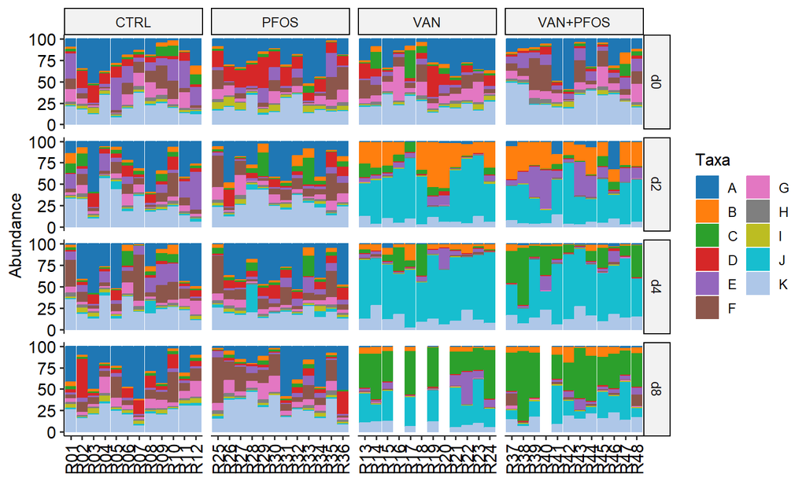

```r
#Melt data
dat <- suppressWarnings(psmelt(phy.top))
colnames(dat)[c(1,4)] <- c("Taxa","SampleID")

# Sort taxa
dat.sort <- sort_taxa(dat)

# rename taxa
levels(dat.sort$Taxa) <- LETTERS[seq(length(levels(dat.sort$Taxa)))]

# ensure that the variables are factors
dat.sort[,params$time_var] <- factor(dat.sort[,params$time_var])
dat.sort[,params$subject_var] <- factor(dat.sort[,params$subject_var])
dat.sort[,params$group_var] <- factor(dat.sort[,params$group_var])

# Create plot
p <- ggplot(dat.sort, aes(x = .data[[params$subject_var]],
                          y = Abundance,
                          fill = Taxa,
                          color = Taxa)) +
  geom_col() +
  xlab("") +
  facet_grid(get(params$time_var) ~ get(params$group_var),
             space = "free_x",scales = "free_x") +
  ggsci::scale_color_d3(palette = "category20") +
  ggsci::scale_fill_d3(palette = "category20") +
  guides(fill=guide_legend(ncol=2), color=guide_legend(ncol=2)) +
  theme_pubr(legend = "right") + rotate_x_text(angle = 90)
p
```

```r
# print tax table
# print tax table
tax <- dat.sort %>% distinct(Taxa,.keep_all = T) %>% select(Taxa, Kingdom, Phylum, Class, Order,Family,Genus,Species)

kable(tax,digits = 2,caption = paste("Taxa plotted", sep = " ")) %>%
  kable_classic(full_width = F, position = "left")
```

Taxa plotted

| Taxa | Kingdom | Phylum | Class | Order | Family | Genus | Species |
| --- | --- | --- | --- | --- | --- | --- | --- |
| J | Bacteria | Proteobacteria | Gammaproteobacteria | Enterobacterales | Enterobacteriaceae | Escherichia/Shigella | albertii/boydii/coli/coli,/dysenteriae/fergusonii/flexneri/sonnei/vulneris |
| C | Bacteria | Bacteroidetes | Bacteroidia | Bacteroidales | Bacteroidaceae | Bacteroides | xylanisolvens |
| A | Bacteria | Actinobacteria | Actinobacteria | Bifidobacteriales | Bifidobacteriaceae | Bifidobacterium | pseudolongum |
| K | Others | Others | Others | Others | Others | Others | Others |
| F | Bacteria | Firmicutes | Clostridia | Clostridiales | Lachnospiraceae | Family_Lachnospiraceae | Family_Lachnospiraceae |
| B | Bacteria | Bacteroidetes | Bacteroidia | Bacteroidales | Bacteroidaceae | Bacteroides | thetaiotaomicron |
| D | Bacteria | Firmicutes | Bacilli | Lactobacillales | Lactobacillaceae | Lactobacillus | intestinalis |
| E | Bacteria | Firmicutes | Bacilli | Lactobacillales | Lactobacillaceae | Ligilactobacillus | Genus_Ligilactobacillus |
| G | Bacteria | Firmicutes | Clostridia | Clostridiales | Ruminococcaceae | Family_Ruminococcaceae | Family_Ruminococcaceae |
| I | Bacteria | Firmicutes | Erysipelotrichia | Erysipelotrichales | Erysipelotrichaceae | Turicibacter | Genus_Turicibacter |
| H | Bacteria | Firmicutes | Clostridia | Clostridiales | Ruminococcaceae | Intestinimonas | Genus_Intestinimonas |

```r
# clear the environment and release memory
rm(list = ls(all.names = TRUE))
invisible(gc())
```

# FINAL COMMENT

This completes the microbiome description.

To begin the statistical analysis of the data you are now ready for the following steps:

| Analysis | Template | Note |
| --- | --- | --- |
| Statistical testing | GMH_test_variables | Statistical test of sample_data variables, incl alpha diversity |
| Beta diversity | GMH_betadiversity | Statistical test of beta diversity and visualization |
| Differential abundance | GMH_differential_abundance | Test differential abundance of taxa against sample variables |

# SETTINGS

Overview of the parameters and packages that were used for this Rmarkdown.

## PARAMETERS

The following paramenters were set in for this analysis:

```r
params <- readRDS( "R_objects/params_description")


tmp <- unlist(params)
dat <- data.frame(Parameter = names(tmp), Value = unname(tmp))


kbl(dat, row.names = F) %>% kable_classic(lightable_options = "striped")
```

| Parameter | Value |
| --- | --- |
| input | R_objects/Phyloseq_15000.Rdata |
| group_var | treatment |
| subject_var | rat_name |
| time_var | day |